# Basic Histology: Smart Study Notes

### The core idea

Four gland systems share one duct system and one embryological origin: the salivary glands **lubricate and begin digestion**, the pancreas **digests**, the liver **processes**, and the gallbladder **stores**. Each is built around its job, and each has one histologic signature that identifies it.

### Salivary Glands

The three major pairs produce about **90%** of saliva; minor glands scattered through the oral mucosa contribute the rest. Total output is **0.75–1.5 L/day**.

| Gland | Secretory units | Secretion |
| --- | --- | --- |
| **Parotid** | **Serous acini only** | Watery, enzyme-rich |
| **Submandibular** | Mixed, **mainly serous** acini | Mixed |
| **Sublingual** | Mixed, **mainly mucous tubules**, some with **serous demilunes** (partly a fixation artifact) | Viscous |

**Serous cells** are protein-secreting and form round or oval acini; **mucous cells** secrete mucin and form elongated tubules. **Myoepithelial cells** sit between the secretory cells and the basal lamina and squeeze the secretion onward.

The duct system is a three-step sequence, and each step has a different epithelium:

1. **Intercalated ducts** — simple cuboidal; the smallest.
2. **Striated ducts** — simple columnar, with **mitochondria-lined basolateral folds** that reabsorb **Na⁺ and Cl⁻** and add **HCO₃⁻**. This is why saliva is **hypotonic** and why the striated duct is the histologic signature of a salivary gland.
3. **Interlobular (excretory) ducts** — unusually, lined by **stratified cuboidal or columnar** epithelium.

### Pancreas

A compound acinar gland, entirely **exocrine** except for the scattered **islets of Langerhans**. It secretes about **1.5 L/day** of alkaline juice.

- **Acinar cells** — **pyramidal**, with a basal nucleus, abundant **rough ER and Golgi** in the basal cytoplasm, and **eosinophilic zymogen granules** apically. The cell is polarized for export: make protein at the base, package it at the apex.
- **Centroacinar cells** — pale cells inserted into the acinar lumen; they begin the duct system *inside* the acinus.
- **Ducts** — intercalated → intralobular → interlobular → main pancreatic duct. **Centroacinar and intercalated duct cells secrete HCO₃⁻** under **secretin**, neutralizing chyme and establishing the pH at which pancreatic enzymes work. The high pH also keeps the enzymes inactive until they reach the duodenum.
- **Endocrine islets** — pale, round clusters between acini (details in Chapter 20).

The pancreas has only a **very thin capsule**, whose septa carry the larger vessels and ducts and separate the parenchyma into lobules; each acinus is surrounded by a basal lamina and a delicate reticular sheath — a useful contrast with the parotid, which has striated ducts and no islets.

### Liver

The liver is both an **endocrine** gland (plasma proteins into blood) and an **exocrine** gland (bile into ducts). That dual output explains its unusual architecture: two fluid streams run in opposite directions through the same lobule.

**Blood supply.** About **75%** of hepatic blood is nutrient-rich, O₂-poor **portal vein** blood; **25%** is oxygenated **hepatic artery** blood. Both enter at the portal areas and flow **toward the central vein**.

- **Classic lobule** — a polygon of **plates of hepatocytes radiating toward a central vein**, with **portal areas** at the corners. Connective tissue between lobules is sparse, becoming more abundant in the portal areas.
- **Portal area (triad + one)** — a **portal venule**, a **hepatic arteriole**, a **bile ductule**, and a small **lymphatic**.
- **Hepatocytes** — large polygonal epithelial cells with large central nuclei; about **50% are polyploid** and many are **binucleated**. They contain abundant **rough and smooth ER**, many small **Golgi complexes**, glycogen, and peroxisomes.
- **Sinusoids** — discontinuous, **fenestrated** endothelium. Between endothelium and hepatocytes is the **perisinusoidal space (of Disse)**, where plasma exchanges with hepatocytes.
- **Kupffer cells** — stellate macrophages in the sinusoidal lining; remove effete erythrocytes and release iron and bilirubin.
- **Hepatic stellate (Ito) cells** — in the perisinusoidal space, storing **vitamin A** and other fat-soluble vitamins in lipid droplets; they become myofibroblasts in fibrosis.
- **Bile canaliculi** — grooves **between adjacent hepatocytes**, sealed by tight junctions. Bile flows **toward** the portal area while blood flows **away** from it.
- **Canals of Hering** — where canaliculi join the bile ductules; all ducts eventually form the left and right hepatic ducts.

**Functions:** carbohydrate, lipid, and protein metabolism; **albumin** and clotting factor synthesis; detoxification by SER and peroxisomes; bile production; bilirubin conjugation; storage of glycogen, iron, and vitamins A, D, and B₁₂.

**Zonation.** **Zone I** (periportal) receives the most oxygen and nutrients and performs oxidative metabolism, such as protein synthesis; **zone III** (pericentral) receives the least, and its cells are the first to accumulate fat and undergo ischemic necrosis. Zone III is also where drug biotransformation predominates — the basis for many patterns of hepatic injury.

### Biliary Tract & Gallbladder

Every bile-conducting structure after the canaliculi is lined by **cholangiocytes** — simple cuboidal or columnar epithelium.

**Route:** canaliculi → canals of Hering → bile ductules → interlobular ducts → left and right hepatic ducts → **common hepatic duct** → **cystic duct** → gallbladder → **cystic duct** → **common bile duct** → **hepatopancreatic ampulla (of Vater)** → duodenum.

The **gallbladder** is a sac with a **highly folded mucosa**, a well-vascularized lamina propria, **no muscularis mucosae or submucosa**, and a **muscularis of interwoven bundles**. Its columnar cholangiocytes **absorb water**, concentrating bile; the muscle contracts under **cholecystokinin (CCK)** released by duodenal enteroendocrine cells when food arrives.

> **CLINICAL** — **Cirrhosis** is the end result of hepatocyte injury: fibrosis with regenerative nodules, portal hypertension, and synthetic failure. **Acute pancreatitis** is autodigestion by prematurely activated enzymes; **chronic pancreatitis** destroys acini and islets, producing diabetes and steatorrhea. **Carcinoma of the head of the pancreas** obstructs the common bile duct and produces painless obstructive jaundice. **Gallstones** form when bile is supersaturated with cholesterol or pigment; impaction in the cystic or common bile duct produces biliary colic and obstructive jaundice.

> **MICRO** — The liver is recognized by **cords of eosinophilic cells with central veins and portal areas**. The pancreas by **dark purple acini with pink apical granules and pale islets**. Pancreas versus parotid: the pancreas has **islets** and **no striated ducts**; the parotid has **striated ducts** and **no islets**.

> **TIP** — Bile flows **toward** the portal triad; blood flows **away** from it. The common error is to memorize “everything flows to the center”.

### Chapter 16 — summary

- Major salivary glands make ~90% of saliva; minor glands ~10%.
- Parotid = serous only. Submandibular = mixed, mainly serous. Sublingual = mixed, mainly mucous with demilunes.
- Intercalated duct = simple cuboidal; striated duct = simple columnar with basal folds; excretory duct = stratified cuboidal or columnar.
- Striated ducts reabsorb Na⁺ and Cl⁻ and add HCO₃⁻, making saliva hypotonic.
- Myoepithelial cells contract to expel secretion.
- Pancreatic acinar cell: basal RER and Golgi, apical zymogen granules — polarized for export.
- Centroacinar cells sit inside the acinus and begin the duct.
- Secretin drives HCO₃⁻ secretion from centroacinar and intercalated duct cells.
- Liver blood: 75% portal vein, 25% hepatic artery.
- Portal area = portal venule + hepatic arteriole + bile ductule + lymphatic.
- About half of hepatocytes are polyploid; many are binucleated.
- Kupffer cells = sinusoidal macrophages. Ito cells = vitamin A storage.
- Bile canaliculi lie between hepatocytes, sealed by tight junctions, and drain to the canals of Hering.
- Hepatic zone 1 = periportal, most oxygen; zone 3 = pericentral, most biotransformation and first to die in ischemia.
- Gallbladder: folded mucosa, no muscularis mucosae, no submucosa; cholangiocytes absorb water; CCK contracts the muscle.

### Active recall

1. **Which salivary gland is purely serous?** — The parotid. Submandibular is mixed, mainly serous; sublingual is mixed, mainly mucous.
2. **What do striated ducts do?** — Reabsorb Na⁺ and Cl⁻ and add HCO₃⁻, making saliva hypotonic.
3. **What do centroacinar cells secrete, and under what hormone?** — Bicarbonate-rich fluid, under secretin.
4. **Trace bile from canaliculus to duodenum.** — Canaliculi → canals of Hering → bile ductules → interlobular ducts → hepatic ducts → common hepatic duct → cystic duct → gallbladder → cystic duct → common bile duct → hepatopancreatic ampulla.
5. **Which way does blood flow in a hepatic lobule?** — From portal areas at the periphery toward the central vein.

### Exam-style question

**A liver biopsy shows a portal area containing a venule, an arteriole, a bile ductule, and a lymphatic. Which structure is missing from the center of the lobule?**

A. Central vein  
B. Portal vein  
C. Hepatic artery  
D. Bile duct

**Answer: A** — The portal triad (plus lymphatic) sits at the lobule corner; the central vein sits at the center.

### Practical identification

In a salivary gland, distinguish serous acini, mucous tubules and demilunes, and identify intercalated and striated ducts. In the pancreas, find acini with basal basophilia and apical zymogen granules, plus pale islets. In the liver, identify the lobule, central vein, portal area, plates of hepatocytes and sinusoids, and trace the direction of blood and bile.

In the gallbladder, note the folded mucosa and muscle bundles with no muscularis mucosae.

## 17 · The Respiratory System

**SPECIALTY EXAM:** `INTERNAL MEDICINE`

**In this chapter:** Nasal Cavities · Pharynx · Larynx · Trachea · Bronchial Tree & Lung · Lung Vasculature & Nerves · Pleural Membranes · Respiratory Movements

### Chapter mind map — see the whole first

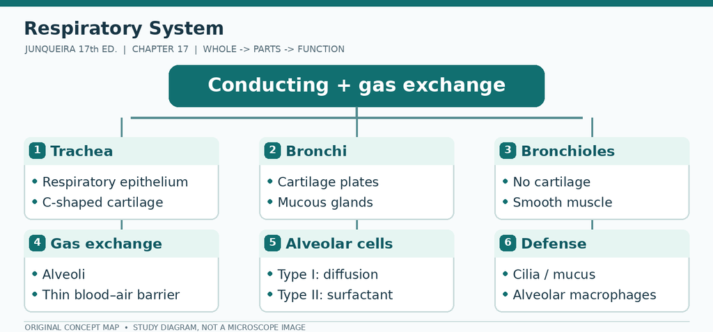

Chapter 17 original concept map: Conducting + gas exchange; branches for Trachea, Bronchi, Bronchioles, Gas exchange, Alveolar cells, Defense

**Two pathways to remember**

- **Composition:** Airway → trachea → bronchus → bronchiole → respiratory bronchiole → alveolus
- **Progression:** Alveolar lining → type I (exchange) + type II (surfactant)

### Quick notes — understand in 90 seconds

- **Trachea:** respiratory epithelium, seromucous glands and C-shaped hyaline cartilage.
- **Bronchus:** cartilage plates and glands within the lung.
- **Bronchiole:** no cartilage or submucosal glands; smooth muscle remains prominent.
- **Respiratory bronchiole:** airway wall begins to contain alveoli.
- **Type I pneumocytes:** thin surface for gas exchange; **type II:** produce surfactant and replenish cells.
- **Alveolar macrophages:** immune defense in air spaces.

**High-yield comparison:** **Bronchus vs bronchiole:** cartilage and glands indicate bronchus.

> **MNEMONIC** — Airway sequence: **trachea → bronchus → bronchiole → alveoli**.

**Recall without looking:** Which epithelial cell secretes pulmonary surfactant?

### Learning objectives

By the end of this chapter you should be able to:

1. Follow the airway from nose to alveolus and name what changes at each level.
2. Identify respiratory epithelium and its cell types.
3. Explain the blood–air barrier, surfactant, and the mechanics of ventilation.
4. Distinguish conducting from respiratory airways in a micrograph.

### The core idea

The respiratory tract is a **conducting** series (nose to terminal bronchiole) followed by a **respiratory** series (respiratory bronchiole to alveolus). The transition is marked by the disappearance of cartilage and the appearance of alveoli. Walking down the tree, each level loses one structural support and gains a thinner epithelium.

### Nasal Cavities

Each nasal cavity has a **vestibule** where air enters, and **three conchae** projecting from the medial wall that create turbulence and force air over a large mucosal surface.

- **Vestibule** — stratified squamous epithelium with **vibrissae** (stiff hairs) that filter large particles.
- **Respiratory region** — **respiratory epithelium**: pseudostratified ciliated columnar with goblet cells, over a highly vascular lamina propria containing seromucous glands. It warms, humidifies, and cleans air; the cilia sweep mucus toward the pharynx.
- **Olfactory region** — the roof and part of the superior concha: **olfactory epithelium**, about **10 cm²** and up to **100 µm** thick, containing **bipolar olfactory neurons**, supporting cells, and basal stem cells. Each neuron has about **20 long nonmotile cilia** bearing odorant receptors. Olfactory neurons are replaced every **1–2 months** — unusual for neurons. **No goblet cells**, but **Bowman glands** in the lamina propria.

**The respiratory epithelium is a mixed population**, and the proportions are worth remembering:

| Cell | Share | Function |
| --- | --- | --- |
| **Ciliated columnar cells** | Majority | Move the mucus blanket |
| **Goblet cells** | — | Secrete mucus |
| **Brush cells** | ~3% | Chemosensory; short blunt microvilli |
| **Small granule (Kulchitsky) cells** | ~3% | **DNES**; dense-core granules 100–300 nm |
| **Basal cells** | ~30% | Stem cells |

### Pharynx

**Nasopharynx** — respiratory epithelium with **lymphoid tissue** (pharyngeal tonsil) in the lamina propria. **Oropharynx** and **laryngopharynx** — stratified squamous epithelium, continuous with the oral cavity and esophagus. The change from respiratory to stratified squamous epithelium marks where the airway is exposed to abrasion from food.

### Larynx

A short air passage between pharynx and trachea, with skeletal cartilages and intrinsic muscles.

- **Epiglottis** — elastic cartilage, with stratified squamous epithelium on its lingual surface and respiratory epithelium on its laryngeal surface; the switch is abrupt.
- **Vocal folds (true cords)** — **stratified squamous** epithelium, avascular, with the **vocal ligament** and the **vocalis muscle**. Tension and vibration produce sound.
- **False cords (vestibular folds)** — respiratory epithelium and glands.

### Trachea

- **Epithelium** — respiratory epithelium (pseudostratified ciliated columnar with goblet cells); the trachea is **10–12 cm** long and supported by **C-shaped rings** of hyaline cartilage.
- **Lamina propria** — elastic fibers, lymphocytes, seromucous glands.
- **Cartilage** — **C-shaped hyaline rings**, incomplete posteriorly.
- **Trachealis muscle** — smooth muscle bridging the posterior gap, allowing the esophagus to expand.

### Bronchial Tree & Lung

**Bronchi** — the primary bronchus enters each lung and branches repeatedly. Cartilage breaks into **irregular plates** rather than rings, a complete ring of smooth muscle appears, and elastic fibers and glands persist. Each **tertiary (segmental) bronchus** with its branches forms a **bronchopulmonary segment** — a pyramidal portion of lung with its own blood supply, separated from its neighbors by connective tissue septa.

**Bronchioles** — airways of **1 mm or less**, formed after about the **tenth generation** of branching. They have **no cartilage and no glands**, a simple ciliated columnar or cuboidal epithelium, circular smooth muscle, and elastic fibers.

- **Club cells** (formerly Clara cells) replace goblet cells as the main secretory cell; they secrete **surfactant-like material**, help innate immunity, and their **smooth ER P450 system detoxifies inhaled compounds**. They are the progenitor cells of the bronchiolar epithelium.
- **Terminal bronchiole** — the last conducting airway, lined mainly by club cells, with **no alveoli**.

**Respiratory region:** terminal bronchiole → **respiratory bronchiole** (simple cuboidal, interrupted by alveoli) → **alveolar duct** (a linear series of alveoli) → **alveolar sac** (a cluster). Gas exchange begins at the respiratory bronchiole.

| Cell | Shape | Function | Share of alveolar lining |
| --- | --- | --- | --- |
| **Type I pneumocyte** | Squamous, extremely thin | **Gas exchange**; forms the blood–air barrier | Lines almost the **entire** alveolar surface |
| **Type II pneumocyte** | Cuboidal, **lamellar bodies** | **Surfactant**; innate immunity; progenitor for type I | A **small part** of each alveolus |
| **Alveolar macrophage** | Large, free (“dust cell”) | Phagocytosis | — |

**Numbers to know:**

- Each alveolus is about **200 µm** across. Each adult lung has about **200 million alveoli**, with a total internal surface area of about **75 m²**.
- The **blood–air barrier** = surfactant film + **type I pneumocyte** + fused basal laminae + capillary endothelium. Its total thickness is **0.1–1.5 µm**, and the attenuated type I cytoplasm can be as thin as **25 nm**.
- **Surfactant** is an oily mixture of **cholesterol, phospholipids, and surfactant proteins** secreted by **type II cells and club cells**. It lowers surface tension and prevents alveolar collapse at end-expiration.
- **Pores of Kohn** — **10–15 µm** openings that connect adjacent alveoli and equalize air pressure.

### Lung Vasculature & Nerves

The lung has a **double blood supply**: the **pulmonary artery** carries deoxygenated blood for gas exchange and forms a dense capillary network around alveoli, while the **bronchial arteries** (from the aorta) supply the conducting airways and pleura. Pulmonary arteries are unusual in carrying **deoxygenated** blood and in having thin walls suited to low pressure.

Autonomic nerves control bronchial smooth muscle and gland secretion — parasympathetic (vagal) constriction, sympathetic relaxation.

### Pleural Membranes

A **serous membrane** of simple squamous mesothelium over connective tissue: **visceral pleura** covers the lung and is continuous with **parietal pleura** lining the thoracic wall. A thin fluid film lets the layers slide while surface tension holds them together, so the lung follows the chest wall.

### Respiratory Movements

Ventilation is pressure-driven: the **diaphragm** and **external intercostal muscles** enlarge the thoracic cavity, pleural pressure falls, the lung expands passively, and air enters. **Elastic recoil** of the lung and surface tension at the alveolar air–liquid interface drive expiration — precisely why surfactant deficiency causes collapse.

> **CLINICAL** — **Respiratory distress syndrome of the newborn** — immature type II pneumocytes produce insufficient surfactant, so alveoli collapse; treatment is exogenous surfactant and antenatal steroids. **Emphysema** — destruction of alveolar walls enlarges air spaces and reduces surface area. **Asthma** — bronchoconstriction, mucosal edema, eosinophilic inflammation, thickened basement membrane, and smooth muscle hypertrophy. **Chronic bronchitis** — mucus hypersecretion and gland hypertrophy. **Cystic fibrosis** — defective CFTR thickens secretions, causing bronchiectasis and recurrent infection. **Lung cancer** — three main types are described here: **squamous cell carcinoma** (smoking-related, arises in segmental bronchi), **adenocarcinoma** (commonest in non-smokers, arises peripherally in bronchioles and alveoli), and **small cell carcinoma** (less common, highly malignant, arising from small granule Kulchitsky cells of the bronchial epithelium).

> **MICRO** — Walk down the tree and count what disappears. **Cartilage rings + glands = trachea. Cartilage plates + no glands = bronchus. No cartilage, no glands, muscular wall = bronchiole.** Then look for alveoli in the wall: if present, it is a respiratory bronchiole.

> **MNEMONIC** — **“Rings, Plates, None”** for cartilage from trachea → bronchus → bronchiole. And **“Type I for gas, Type II for surfactant, macrophage for garbage.”**

> **TIP** — Club cells are found in **bronchioles**, not alveoli, and are the progenitor cells of the bronchiolar epithelium. A question that places them in the alveolus is testing whether you know the level of the airway.

### Chapter 17 — summary

- The conducting airway is nose → pharynx → larynx → trachea → bronchi → bronchioles → terminal bronchioles.
- Respiratory epithelium is pseudostratified ciliated columnar with goblet cells.
- Cartilage changes down the tree: C-shaped rings → irregular plates → none.
- The respiratory bronchiole is the first airway with alveoli in its wall.
- Type I pneumocytes line almost the entire alveolar surface and form the thin gas-exchange barrier.
- Type II pneumocytes secrete surfactant and divide to replace type I cells.
- The blood–air barrier is surfactant, type I cell, fused basal laminae, and capillary endothelium (0.1–1.5 µm).
- Alveolar macrophages (dust cells) clear particles and debris.
- The pleura is a serous membrane: visceral and parietal layers with a fluid-filled cavity.

### Active recall

1. **What marks the transition from conducting to respiratory airway?** — The appearance of alveoli in the wall — the respiratory bronchiole.
2. **Which cells line almost the entire alveolar surface?** — Type I pneumocytes.
3. **What do type II pneumocytes secrete, and why does it matter?** — Surfactant, which lowers surface tension and prevents alveolar collapse.
4. **Name the components of the blood–air barrier.** — Surfactant film, type I pneumocyte, fused basal laminae, capillary endothelium.
5. **How does cartilage change down the tree?** — C-shaped rings (trachea) → irregular plates (bronchi) → absent (bronchioles).

### Exam-style question

**A premature infant develops respiratory distress because alveoli collapse at end-expiration. Which cell is functionally immature?**

A. Type I pneumocyte  
B. Type II pneumocyte  
C. Alveolar macrophage  
D. Club cell

**Answer: B** — Type II cells produce surfactant; their immaturity causes neonatal respiratory distress syndrome.

### Practical identification

Follow the airway from trachea to alveolus. At each level, record the epithelium, the cartilage (ring, plate or none), the glands (present or absent) and the smooth muscle. Identify type I and type II pneumocytes, an alveolar macrophage, the blood–air barrier and a pore of Kohn. Distinguish a bronchiole from a tangentially cut vessel and from an alveolar duct.

## 18 · Skin

**SPECIALTY EXAM:** `INTERNAL MEDICINE`

**In this chapter:** Epidermis · Dermis · Subcutaneous Tissue · Sensory Receptors · Hair · Nails · Skin Glands · Skin Repair

### Chapter mind map — see the whole first

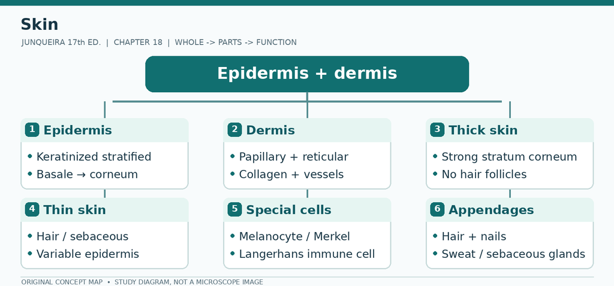

Chapter 18 original concept map: Epidermis + dermis; branches for Epidermis, Dermis, Thick skin, Thin skin, Special cells, Appendages

**Two pathways to remember**

- **Composition:** Skin → epidermis + dermis + subcutaneous tissue
- **Progression:** Epidermis deep → basal → spinous → granular → corneum (lucidum in thick skin)

### Quick notes — understand in 90 seconds

- **Epidermis:** keratinized stratified squamous epithelium.
- Layers from deep to surface: **basale → spinosum → granulosum → corneum**; lucidum is visible in thick skin.
- **Thick skin:** prominent corneum, no hair follicles; **thin skin:** may contain hair and sebaceous glands.
- **Melanocytes:** pigment cells; **Langerhans cells:** antigen-presenting immune cells.
- **Merkel cells:** specialized basal epidermal touch-associated cells.

**High-yield comparison:** **Thick skin ≠ thicker dermis**; diagnose mainly by epidermal thickness and absence of hair follicles.

> **MNEMONIC** — Epidermis (deep → superficial): **B-S-G-C**.

**Recall without looking:** Which skin type has stratum lucidum but lacks hair follicles?

**Visual anchor — simplified schematic:**

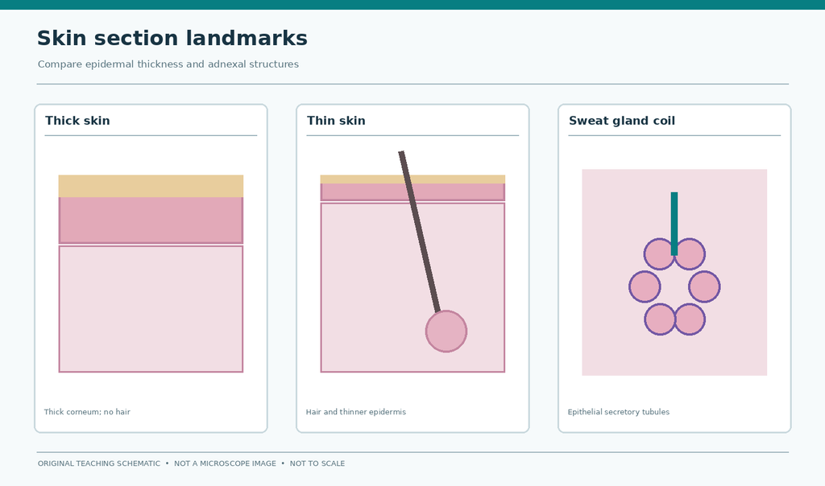

Original schematic comparing thick and hair-bearing skin

### Learning objectives

By the end of this chapter you should be able to:

1. Name the epidermal layers in order and the defining feature of each.
2. Match each epidermal cell type to its origin and function.
3. Identify the dermis, hypodermis, and each skin appendage.
4. Explain the stages of skin repair, and recognize healing by first and second intention.

### The core idea

Skin is a **stratified, keratinizing, self-renewing barrier** with appendages embedded in it. The epidermis is a factory that moves cells outward and turns them into keratin; the dermis provides mechanical and nutritional support; the appendages provide temperature control, sensation, and protection. Every fact in the chapter is a consequence of one of those three jobs.

### Epidermis

**Thickness:** **75–150 µm** in thin skin, **400–600 µm** in thick skin. Full skin (epidermis + dermis) is about **4 mm** on the back and **1.5 mm** on the scalp. The epidermis is **avascular** — nutrients and O₂ arrive by diffusion from the dermal papillae. It turns over about every **15–30 days**.

| Layer | Cells | Key feature |
| --- | --- | --- |
| **Stratum basale** | Mitotic stem cells, melanocytes, Merkel cells | Single layer on the basement membrane, attached by **hemidesmosomes and integrins**; **keratin filaments ~10 nm** first appear here |
| **Stratum spinosum** | Polyhedral cells with **desmosomes** | “Spiny” because shrinkage pulls apart desmosome-bound bundles (**tonofibrils**); **Langerhans cells** live here |
| **Stratum granulosum** | Flattened cells with **keratohyalin granules** and **lamellar granules** | Keratohyalin contains **filaggrin**, which aggregates keratin; lamellar granules discharge lipid into the intercellular space |
| **Stratum lucidum** | Clear, anucleate, refractile | **Only in thick skin** of palms and soles |
| **Stratum corneum** | Anucleate **squames** | The barrier; keratin packed in an electron-dense matrix with a lipid envelope |

Keratin filaments contain at least **six polypeptides of 40–70 kDa**, synthesized as the cell differentiates. The **lipid envelope** between squames is what makes epidermis impermeable to water.

| Cell | Origin | Function | Identifying feature |
| --- | --- | --- | --- |
| **Keratinocyte** | Ectoderm | Barrier, keratin production | 90% of epidermal cells; desmosomes |
| **Melanocyte** | **Neural crest** | **Melanin** via tyrosinase; transferred in melanosomes | Dark, dendritic; basal layer |
| **Langerhans cell** | Mainly embryonic yolk-sac and fetal-liver myeloid precursors; local self-renewal in steady state | Antigen presentation | Dendritic epidermal immune cell, often in stratum spinosum; **2–8%** is an approximate estimate |
| **Merkel cell** | Epidermal ectoderm-lineage progenitors (supported by mammalian fate mapping) | **Light touch** (mechanoreception) | Basal epidermis, with sensory nerve contact; not normally classified as a neural-crest derivative |

**Melanocytes** — about **one per five or six keratinocytes** (**600–1200/mm²** of thin skin), with processes reaching **10–30 keratinocytes**. **Tyrosinase** converts tyrosine to DOPA and then to **eumelanin** (brown-black) or **pheomelanin** (red-yellow). Mature melanosomes are ellipsoid, **0.5 × 1 µm**, and are transferred to keratinocytes, which hold more pigment than the cells that make it. The pigment sits over the nucleus and **protects nuclear DNA from UV damage** — the reason tanning exists and the reason melanoma risk tracks sun exposure. One melanocyte plus its keratinocytes is an **epidermal-melanin unit**. Melanocytes are about **four times more numerous and active in thin skin** than in thick palmar and plantar skin.

**The melanin rule:** densities of epidermal-melanin units are **similar across populations**; what differs is how rapidly melanin is made and how abundantly it accumulates in keratinocytes. Dark skin is not skin with more melanocytes.

### Dermis

- **Papillary dermis** — loose connective tissue forming **dermal papillae** that interdigitate with the epidermis; contains the **subpapillary microvascular plexus**, which sends capillary loops into the papillae.
- **Reticular dermis** — dense irregular connective tissue with thick collagen bundles and elastic fibers; up to **4 mm** thick on the back.

Dermal vasculature has two jobs: **nutrition** (two plexuses, subpapillary and deep) and **thermoregulation** through **arteriovenous anastomoses** between them.

**Thick versus thin skin.** Thick skin (palms, soles) has a thick stratum corneum, a **stratum lucidum**, and **no hair follicles**; it has many sweat glands. Thin skin covers most of the body, has hair follicles and sebaceous glands, and a thinner epidermis.

### Subcutaneous Tissue

The **hypodermis** — loose connective tissue and adipose tissue (**panniculus adiposus**) binding skin loosely to underlying organs, so the skin can slide. It insulates, cushions, stores energy, and determines how a wound behaves and how an injection is absorbed.

### Cutaneous Sensory Receptors

| Receptor | Location | Structure | Modality |
| --- | --- | --- | --- |
| **Free nerve endings** | Epidermis and dermis | Unencapsulated | Pain, temperature extremes, mechanical movement |
| **Merkel cell** | Basal epidermis | Cell + disc-like nerve ending | **Light touch**, sustained pressure |
| **Meissner corpuscle** | Dermal papilla | Elliptical, **~150 µm**, stacked Schwann cells | **Light touch**, fine discrimination |
| **Pacinian corpuscle** | Deep dermis and hypodermis | Oval, **~1 mm**, **15–50 concentric lamellae** | **Pressure and high-frequency vibration** |
| **Krause end bulb** | Penis and clitoris mainly | Thin collagenous capsule | Low-frequency vibration |
| **Ruffini corpuscle** | Dermis | Fusiform capsule anchored to collagen | **Tissue distortion and sustained stretch** |

### Hair

Hairs are keratinized structures formed in **hair follicles**, epidermal invaginations extending into the dermis.

- The **hair bulb** at the base contains the **matrix** (rapidly proliferating keratinocytes) and is invaginated by a vascular **dermal papilla** that supplies it.
- The hair root has three concentric layers — **medulla, cortex, cuticle** — surrounded by **internal and external root sheaths** continuous with the epidermis, a **glassy membrane** (partly basal lamina), and a connective tissue sheath.
- The **arrector pili** smooth muscle raises the hair; a **root plexus** provides sensation.
- Density: about **600 hairs/cm²** on the face and **60/cm²** elsewhere.
- Growth cycles: **anagen** (growth), **catagen** (involution), **telogen** (rest).

### Nails

Hard keratin plates on the dorsal surface of the distal phalanx. The **nail root** lies under a skin fold whose cornified layer forms the **cuticle (eponychium)**; keratinocytes proliferate in the **matrix** and differentiate into the **nail plate**, which slides forward over the **nail bed** (which does not contribute). The **lunula** is the visible part of the matrix.

### Skin Glands

**Sebaceous glands** — **holocrine**: sebocytes accumulate lipid, die, and discharge **sebum** into the hair follicle (pilosebaceous unit). Absent from palms and soles.

**Eccrine sweat glands** — **merocrine**, coiled tubular, with a secretory portion of cuboidal cells and a duct of **stratified cuboidal** cells; abundant on palms and soles; watery sweat for thermoregulation.

**Apocrine sweat glands** — **axillae and perineum**, much **wider lumens**, develop after **puberty**, and secrete protein-rich sweat onto hair follicles; odor follows bacterial action.

### Skin Repair

Repair runs through overlapping stages: a **clot** forms and platelets release growth factors; **neutrophils and macrophages** remove bacteria and debris (inflammation lasts **2–3 days**); fibroblasts proliferate under growth-factor and macrophage signals and produce new collagen while capillaries grow into the site, forming **granulation tissue**; **keratinocytes** from the epidermal basal layer migrate beneath and through the clot and restore epithelial continuity; and excess collagen is left as **scar**.

Epithelialization is complete before the collagen of the scar remodels.

**Standard clinical terminology:** healing by **first intention** — clean, apposed edges needing minimal granulation tissue; **second intention** — an open wound with abundant granulation tissue, wound contraction by myofibroblasts, and a larger scar. **Burns** are graded by depth: first-degree (epidermis), second-degree (into dermis, blistering), third-degree (full thickness, including appendages, so it cannot re-epithelialize).

> **CLINICAL** — **Psoriasis** — T-cell-driven accelerated production and differentiation of keratinocytes, with thickening, scaling, and a defective barrier. **Skin cancer** — about **one-third of all cancers** begin in skin; most arise from basal or spinous cells (basal cell and squamous cell carcinoma), are diagnosed early, and are rarely lethal; incidence rises with fair skin and solar exposure. **Melanoma** — moles can show dysplasia and progress to malignant melanoma, whose cells penetrate the basal lamina and metastasize through blood and lymph. **Merkel cell carcinoma** is **40 times less common** than melanoma but has **twice its mortality**. **Albinism** — defective tyrosinase or another melanin-pathway component; **vitiligo** — loss or reduced activity of melanocytes. **Pemphigus** (intercellular junctions) and **bullous pemphigoid** (dermal–epidermal junction) are the blistering diseases. **Cystic fibrosis** — salty sweat, because CFTR fails to reabsorb salt in the sweat duct.

> **MICRO** — Count layers and look for appendages. **Thick skin: five layers, thick keratin, no hair. Thin skin: four layers, hair follicles and sebaceous glands.** A dark condensed nucleus at the basal layer with a clear halo suggests a melanocyte.

> **TIP** — “Melanocytes are more numerous in dark skin” is false. **Unit density is similar in all people; melanin production and transfer differ.** Also remember that the **nail bed makes no contribution** to the nail plate — the matrix does.

> **MNEMONIC** — **“Come Let’s Get Some Beer”** — **C**orneum, **L**ucidum, **G**ranulosum, **S**pinosum, **B**asale (superficial to deep) — and remember **lucidum exists only in thick skin**.

### Chapter 18 — summary

- Epidermal layers, deep to superficial: basale, spinosum, granulosum, lucidum (thick skin only), corneum.
- Keratinocytes make keratin; they are the most numerous epidermal cells.
- Melanocytes are neural crest cells that transfer melanin to keratinocytes.
- Langerhans cells are antigen-presenting epidermal myeloid cells, largely seeded prenatally from embryonic progenitors and maintained by local self-renewal.
- Merkel cells are mechanoreceptors at the basal layer.
- Dermis = papillary (loose) + reticular (dense irregular); hypodermis is adipose and loose connective tissue.
- Eccrine sweat glands are merocrine; apocrine glands open into hair follicles; sebaceous glands are holocrine.
- Meissner corpuscles sense light touch; Pacinian corpuscles sense pressure and vibration.
- Thick skin has a stratum lucidum and no hair follicles; thin skin has hair and sebaceous glands.

### Active recall

1. **Name the epidermal layers from deep to superficial.** — Basale, spinosum, granulosum, lucidum (thick skin only), corneum.
2. **Distinguish the developmental origins of three nonkeratinocyte epidermal cells.** — Melanocytes arise from the neural crest; Merkel cells arise from epidermal progenitors (supported by mammalian lineage tracing); Langerhans cells are immune-lineage cells seeded mainly by embryonic yolk-sac and fetal-liver precursors.
3. **What is the function of lamellar bodies?** — They discharge lipid into the intercellular space, forming the water barrier.
4. **Where are Meissner and Pacinian corpuscles?** — Meissner in the dermal papillae (light touch); Pacinian deep in the dermis/hypodermis (pressure, vibration).
5. **How do sebaceous and eccrine glands differ in secretion?** — Sebaceous: holocrine. Eccrine: merocrine.

### Exam-style question

**A skin section shows a thick stratum corneum, a clear layer, and no hair follicles. Which site is it from?**

A. Scalp  
B. Palm  
C. Back  
D. Axilla

**Answer: B** — Thick skin with a stratum lucidum and no hair follicles is palmar or plantar skin.

### Practical identification

Identify the five epidermal layers in thick skin and the four in thin skin, and find the dermal papilla, the reticular dermis and the hypodermis. Name the appendages: hair follicle with its root sheaths and arrector pili, sebaceous gland (holocrine), eccrine gland (merocrine, coiled) and apocrine gland (wide lumen). Distinguish Meissner from Pacinian corpuscles by location, size and capsule.

# PART V — EXCRETION AND REPRODUCTION

## 19 · The Urinary System

**SPECIALTY EXAM:** `SURGERY`

**In this chapter:** Kidneys · Blood Circulation · Renal Function: Filtration, Secretion, & Reabsorption · Ureters, Bladder, & Urethra

### Chapter mind map — see the whole first

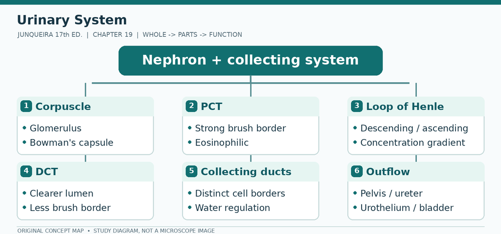

Chapter 19 original concept map: Nephron + collecting system; branches for Corpuscle, PCT, Loop of Henle, DCT, Collecting ducts, Outflow

**Two pathways to remember**

- **Composition:** Nephron → renal corpuscle → PCT → loop → DCT → collecting system
- **Progression:** Filtration barrier → fenestrated endothelium + GBM + podocyte slit diaphragm

### Quick notes — understand in 90 seconds

- **Renal corpuscle:** glomerular capillary tuft within Bowman’s capsule.
- **PCT:** eosinophilic cells and conspicuous apical brush border; often indistinct lumen.
- **DCT:** clearer lumen and little/no prominent brush border.
- **Collecting ducts:** relatively distinct cell boundaries in larger profiles.
- **Juxtaglomerular apparatus:** close relationship of macula densa, granular cells and vascular pole.
- **Urothelium:** lines renal pelvis, ureter and bladder.

**High-yield comparison:** **PCT = brush border + fuzzy lumen; DCT = cleaner lumen**.

> **MNEMONIC** — Start at the **renal corpuscle**, then compare nearby tubules.

**Recall without looking:** Which cortical tubule has a strong brush border?

**Visual anchor — simplified schematic:**

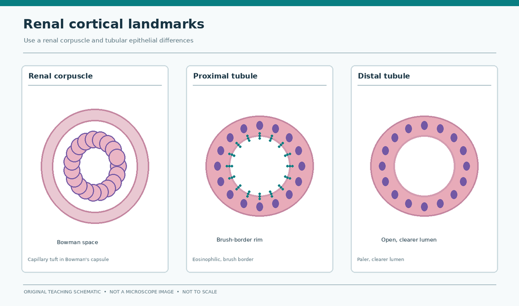

Original schematic comparing renal corpuscle and tubules

### Learning objectives

By the end of this chapter you should be able to:

1. Trace filtrate from glomerulus to ureter, naming each segment and its epithelium.
2. Explain the three layers of the filtration barrier and how each contributes to selectivity.
3. Describe the juxtaglomerular apparatus and its role in blood-pressure control.
4. Identify urothelium and explain how it protects against hypertonic urine.

### The core idea

The kidney is a **countercurrent filtration and reabsorption machine** built from millions of identical tubes. Each segment of the tubule has a distinct epithelium matched to a distinct transport job, so identifying the segment from its histology is the same as naming its function.

### Kidneys

Each kidney is bean-shaped, about **12 cm long, 6 cm wide, and 2.5 cm thick** in adults, with a convex lateral border and a concave medial **hilum**, which admits nerves and vessels and lets the ureter and lymphatics exit. Inside the hilum the ureter expands as the **renal pelvis**, which divides into **two or three major calyces**, then **minor calyces**.

- **Capsule** → **cortex** (renal corpuscles + convoluted tubules) → **medulla** (loops of Henle, collecting ducts, vasa recta) organized into **8–15 pyramids** (some descriptions give 8–12; both counts are in use).
- **Renal columns (of Bertin)** — cortical tissue between pyramids.
- **Lobe** = pyramid + overlying cortex; **lobule** = a medullary ray + the cortical tissue around it.
- **Papilla** → minor calyx → major calyx → renal pelvis → ureter.
- The cortex receives **more than 10 times** the blood flow of the medulla.

**The nephron** — about **1.25 million per kidney** — begins with the **renal corpuscle**: the **glomerulus** (a tuft of fenestrated capillaries) inside the **glomerular (Bowman) capsule**.

- **Parietal layer** — simple squamous epithelium, continuous with the proximal tubule.
- **Visceral layer** — **podocytes** with primary processes and interdigitating **pedicels** that embrace the capillaries. Between pedicels are **filtration slit pores**, bridged by a zipper-like **slit diaphragm** of P-cadherin, **nephrins**, and the negatively charged glycoprotein **podocalyxin**.
- **Mesangial cells** — between capillaries, covering surfaces not covered by podocytes; **contractile** (like pericytes) and produce external lamina.

**The filtration barrier has three layers:** **fenestrated endothelium** → **glomerular basement membrane (GBM)**, about **330 nm** thick, of **type IV collagen** and other proteins made by endothelial cells and podocytes → **podocyte slit diaphragms**. The barrier restricts macromolecules through its structural organization and molecular interactions; **size selectivity is well established, while the independent contribution of charge selectivity is more complex than a simple two-filter model suggests**.

**Functional numbers to know:**

- Total filtration area ≈ **500 cm²**.
- **GFR ≈ 125 mL/min**, or about **180 L/day**.
- Plasma volume ≈ **3 L**, so the kidneys filter a volume equal to the whole plasma volume about **60 times a day**.

**Juxtaglomerular apparatus (JGA)** — at the vascular pole: **juxtaglomerular (JG) cells** in the afferent arteriole (modified smooth muscle, contain **renin**), the **macula densa** (a plaque of tall, closely packed cells in the distal straight tubule sensing NaCl), and **extraglomerular mesangial (lacis) cells**.

### Reading a Renal Biopsy: A Step-by-Step Method

A renal section becomes easier to interpret when you separate **location**, **compartment**, and **cellular detail** rather than guessing a diagnosis from a single structure.

1. **Orient the specimen.** Renal corpuscles establish that cortex is present. Medullary tissue lacks corpuscles and contains parallel loops, vessels and collecting ducts. A small biopsy may not sample every compartment.
2. **Examine the glomeruli.** Locate the capillary tuft, Bowman’s space, parietal epithelium and mesangial regions. Ask whether the tuft is open and delicate or crowded by cells or matrix. Do not diagnose a specific glomerular disease from routine light microscopy alone.
3. **Compare tubules.** Proximal tubules generally have strongly eosinophilic cytoplasm and a prominent apical brush border, so their lumina often look irregular or partly obscured. Distal tubules usually have clearer lumina and less conspicuous apical microvilli. Section angle and fixation can alter both appearances.
4. **Assess the interstitium and vessels.** Note the amount of connective tissue between tubules, inflammatory cells if present, and arterial or arteriolar wall changes. These compartments can be as important as the glomeruli.
5. **Connect appearance to function.** A damaged filtration barrier may permit albumin to enter urine; tubular injury can impair reabsorption and concentration. Neither finding establishes a diagnosis without clinical information and appropriate laboratory tests.

**Microscopy caution.** Standard renal-biopsy interpretation often integrates light microscopy with immunofluorescence and electron microscopy. For example, immune deposits and podocyte foot-process changes may not be characterized adequately on a routine H&E slide.

**Active identification task.** On a low-power renal cortex image, identify one corpuscle, two proximal tubules and two distal tubules. For each identification, state two positive features and one potential source of error.

### Blood Circulation

Renal artery → segmental → interlobar (between pyramids) → arcuate (at the corticomedullary junction) → interlobular (radiating into the cortex) → **afferent arteriole** → glomerulus → **efferent arteriole** → peritubular capillaries in the cortex and **vasa recta** in the medulla. The **efferent arteriole**, not a venule, drains the glomerulus — an arrangement that keeps glomerular hydrostatic pressure high.

Efferent arterioles of **cortical** glomeruli branch into a diffuse peritubular network; those of **juxtamedullary** glomeruli form the long hairpin **vasa recta** that run alongside the loops of Henle and participate in **countercurrent exchange**, helping preserve the medullary osmotic gradient. The **loops of Henle**, especially their thick ascending limbs, are central to countercurrent multiplication.

### Renal Function: Filtration, Secretion, & Reabsorption

[output not shown]

**Size contrast:** the straight proximal tubule is about **60 µm** in outer diameter and narrows abruptly to about **30 µm** in the thin limbs of the loop.

The visual contrast that answers most questions: the **proximal tubule is eosinophilic with a ragged brush border and a star-shaped lumen; the distal tubule is pale with a clean lumen and no brush border.**

**Collecting ducts.** Connecting tubules from several nephrons join to form cortical collecting ducts, which enter the medulla parallel to the loops and vasa recta and become larger with more columnar cells. The largest (papillary) ducts — **ducts of Bellini** — open into a minor calyx, where filtrate undergoes no further modification and is called **urine**.

### Ureters, Bladder, & Urethra

**Ureter** — **urothelium (transitional epithelium)**, a folded mucosa, and a **thick muscularis** that moves urine by peristalsis; inner longitudinal and outer circular layers, with a third layer added near the bladder. **Bladder** — urothelium, a highly folded mucosa, and the **detrusor** muscle in three poorly delineated interlacing layers. It holds **400–600 mL**, with the urge to void at about **150–200 mL**.

**Urothelium is a specialized barrier, not just a stratified epithelium:**

- **Umbrella cells** — large superficial cells up to **100 µm** in diameter, with **uroplakin-containing membrane plaques**, hinged to allow unfolding as the bladder fills.
- The epithelium is organized in **three layers**: superficial **umbrella cells**, an intermediate layer of cuboidal or low columnar cells (one to several deep), and a basal layer. Emptying folds the mucosa and lets umbrella cells retract folded plaques; filling flattens the cells and thins the epithelium.
- Tight junctions plus plaques make it an osmotic barrier against hypertonic urine.

**Urethra** — in both sexes lined initially by urothelium. In men there are three parts: **prostatic** (3–4 cm, urothelium), **membranous** (short, through the urogenital diaphragm; stratified or pseudostratified columnar), and **penile** (long; stratified columnar/pseudostratified proximally, stratified squamous distally). In women the urethra is **3–5 cm**, urothelium proximally, then nonkeratinized stratified squamous; the middle part is surrounded by the **external striated sphincter**. The short female urethra explains the frequency of cystitis.

> **CLINICAL** — **Polycystic kidney disease** — inherited cysts arising from nephron epithelium destroy cortical organization. **Glomerulonephritis** — immune-complex or anti-glomerular antibody injury; **proteinuria** means the filter has become permeable to protein. **Diabetic glomerulosclerosis** — thickening and loss of function of the GBM; the leading cause of end-stage kidney disease in the United States. **Sickle cell nephropathy** — sickling in the vasa recta causes papillary infarcts. **Kidney stones** — calculi form in the pelvis or calyces, usually from calcium oxalate/phosphate or uric acid. **Pyelonephritis** — bacteria reach the papilla from a calyx; **cystitis** — the commonest bladder problem, favored in women by the short urethra.

> **MICRO** — Start at the renal corpuscle: the **glomerulus** is a tuft of capillaries inside a capsule. Then compare tubules: **eosinophilic + brush border = proximal; pale + clean = distal; large pale cells in a row = collecting duct.** The **macula densa** is the patch of tall cells on the distal tubule facing the vascular pole.

> **TIP** — The proximal tubule is the **most eosinophilic** structure in the renal cortex, packed with mitochondria for active transport. Students often call it “basophilic” because the brush border looks fuzzy — the cytoplasm is pink.

### Chapter 19 — summary

- Kidney: **8–15 pyramids**; about **1.25 million nephrons**.
- Lobe = pyramid + cortex; lobule = medullary ray + surrounding cortex.
- Cortex receives **more than 10×** the blood flow of the medulla.
- Afferent arteriole → glomerulus → **efferent arteriole** (not a venule), keeping glomerular pressure high.
- Filtration area ≈ **500 cm²**; GFR ≈ **125 mL/min ≈ 180 L/day**.
- Filtration barrier = fenestrated endothelium + **GBM (type IV collagen, ~330 nm)** + slit diaphragms (nephrin, podocalyxin).
- Mesangial cells are contractile and support the capillary tuft.
- **PCT**: brush border, eosinophilic, reabsorbs all glucose and small proteins.
- **TAL**: water-impermeable, reabsorbs NaCl, ends as the **macula densa**.
- **JG cells** in the afferent arteriole secrete **renin**; macula densa senses NaCl.
- Collecting duct: **principal cells** (aquaporins, ADH) and **intercalated cells** (acid–base transport).
- Urothelium: three layers — umbrella cells with uroplakin plaques above intermediate and basal cells; it thins as the bladder fills.
- Bladder holds **400–600 mL**; urge at **150–200 mL**.
- Male urethra: prostatic, membranous, penile; female urethra 3–5 cm — short, hence cystitis.

### Active recall

1. **Which nephron segment is most eosinophilic, and why?** — The proximal convoluted tubule: abundant mitochondria and a brush border for active reabsorption.
2. **What are the three layers of the filtration barrier?** — Fenestrated endothelium, glomerular basement membrane, and podocyte slit diaphragms.
3. **What does the macula densa sense, and what does the JGA release?** — NaCl concentration; juxtaglomerular cells release renin.
4. **Which cells of the collecting duct respond to ADH?** — Principal cells, by inserting aquaporins into the apical membrane.
5. **What makes urothelium a barrier?** — Umbrella cells with uroplakin plaques and tight junctions.

### Exam-style question

**A patient has proteinuria from podocyte injury. Which layer of the filtration barrier is primarily affected?**

A. Fenestrated endothelium  
B. Glomerular basement membrane  
C. Podocyte slit diaphragms  
D. Mesangial matrix

**Answer: C** — Podocyte foot processes and their slit diaphragms form the final size filter; their loss produces proteinuria.

### Practical identification

In the cortex, distinguish proximal from distal convoluted tubules by cytoplasm, brush border and lumen; find a renal corpuscle and identify its parietal layer, podocytes and mesangial cells. In the medulla, identify thin and thick limbs and collecting ducts. Trace the vascular route from interlobular artery to peritubular capillary or vasa recta. In the bladder, identify urothelium with umbrella cells and the detrusor muscle.

## 20 · Endocrine Glands

**SPECIALTY EXAM:** `INTERNAL MEDICINE`

**In this chapter:** Pituitary Gland (Hypophysis) · Adrenal Glands · Pancreatic Islets · Diffuse Neuroendocrine System · Thyroid Gland · Parathyroid Glands · Pineal Gland

### Chapter mind map — see the whole first

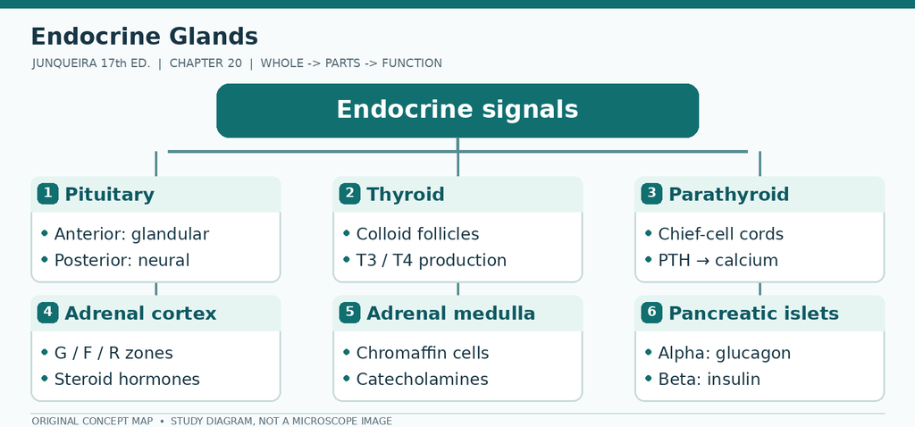

Chapter 20 original concept map: Endocrine signals; branches for Pituitary, Thyroid, Parathyroid, Adrenal cortex, Adrenal medulla, Pancreatic islets

**Two pathways to remember**

- **Composition:** Endocrine tissue → follicles (thyroid) / cords (parathyroid) / zones (adrenal)
- **Progression:** Adrenal cortex → glomerulosa (aldosterone) → fasciculata (cortisol) → reticularis (androgens)

### Quick notes — understand in 90 seconds

- **Pituitary:** anterior glandular cells and posterior neural tissue; hormones differ by region.
- **Thyroid:** follicles filled with colloid; follicular cells synthesize T3/T4.
- **Parathyroid:** endocrine chief-cell cords and capillaries, not colloid follicles.
- **Adrenal cortex:** glomerulosa (mineralocorticoids), fasciculata (glucocorticoids), reticularis (androgens).
- **Adrenal medulla:** catecholamine-producing chromaffin cells.
- **Thyroid C cells:** secrete calcitonin; mammalian embryologic origin differs from older exclusively neural-crest accounts.

**High-yield comparison:** **Thyroid = follicles; parathyroid = cell cords; adrenal cortex = three zones**.

> **MNEMONIC** — Adrenal cortex: **G-F-R = salt, sugar, sex-related steroids** (simplified).

**Recall without looking:** Which endocrine organ stores hormone precursors extracellularly in colloid?

**Visual anchor — simplified schematic:**

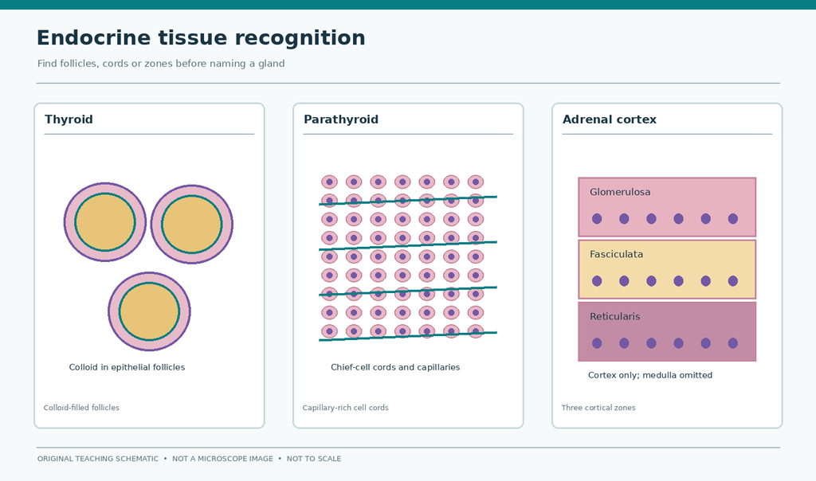

Original schematic comparing thyroid, parathyroid and adrenal cortex

### Learning objectives

By the end of this chapter you should be able to:

1. Classify endocrine organs by their architectural pattern (cords, follicles, clusters).
2. Map each pituitary hormone to its cell type and hypothalamic control.
3. Match each adrenal zone to its hormone and trophic control.
4. Distinguish thyroid, parathyroid, and pineal tissue in a micrograph.

### The core idea

Endocrine glands release hormone into the blood, so their histology is organized around **storage and release** rather than ducts. The three patterns to recognize are **cords** (pituitary, adrenal, parathyroid), **follicles** (thyroid), and **clusters** (pancreatic islets). Each pattern is dictated by how the hormone is stored.

### Pituitary Gland (Hypophysis)

Two embryologically distinct parts in one sella turcica.

**Adenohypophysis** (oral ectoderm — **Rathke’s pouch**). The **pars distalis accounts for 75%** of the adenohypophysis and is covered by a thin fibrous capsule:

| Region | Cells | Hormones |
| --- | --- | --- |
| **Pars distalis** | **Acidophils** | **GH, prolactin** |
|  | **Basophils** | **ACTH, TSH, FSH, LH** |
|  | **Chromophobes** | Inactive or degranulated |
| **Pars intermedia** | Basophils, colloid cysts | MSH (rudimentary in humans) |
| **Pars tuberalis** | — | Wraps the infundibulum |

**Reading the stain.** Routine H&E divides the pars distalis into **acidophils** (pink), **basophils** (blue), and **chromophobes** (poorly stained, the least numerous). The modern names describe the hormone, not the color: **somatotrophs** (GH), **lactotrophs** (prolactin), **corticotrophs** (ACTH), **thyrotrophs** (TSH), and **gonadotrophs** (FSH, LH). Acidophils are the somatotrophs and lactotrophs; basophils are the corticotrophs, thyrotrophs, and gonadotrophs.

**Neurohypophysis** (neuroectoderm): the **pars nervosa** stores **oxytocin and ADH (arginine vasopressin)** — both **9-amino-acid peptides** — synthesized in the **supraoptic and paraventricular nuclei** of the hypothalamus and carried down axons. In the axon terminals they are bound to **10-kDa carrier proteins, neurophysin I and II**, and accumulate in dilatations called **neurosecretory (Herring) bodies**, visible as faintly eosinophilic structures. **Pituicytes** are the glial cells of the lobe. The neurohypophysis **makes no hormone of its own** — it stores and releases hypothalamic hormones.

**Control:** the hypothalamus releases **releasing and inhibiting hormones** into the **hypophyseal portal system**, carrying them directly to the pars distalis — which is why a tiny hypothalamic signal controls a large pituitary output.

### Adrenal Glands

Two glands in one organ, with entirely different embryology and function:

| Region | Cells | Hormone | Control |
| --- | --- | --- | --- |
| **Zona glomerulosa** | Rounded or arched cords under the capsule, **~15% of the cortex** | **Aldosterone** | **Angiotensin II, K⁺** |
| **Zona fasciculata** | Long cords of pale, foamy cells | **Cortisol** | **ACTH** |
| **Zona reticularis** | Irregular cords, pigmented cells | **Androgens (DHEA)** | ACTH |
| **Medulla** | **Chromaffin cells** (neural crest) | **Epinephrine, norepinephrine** | Sympathetic splanchnic nerve |

Each adrenal gland is a flattened half-moon about **4–6 cm long, 1–2 cm wide, and 4–6 mm thick**, weighing about **8 g** in total. The **fasciculata** is the **thickest** zone, and its cells are pale and vacuolated because they are full of **lipid droplets (cholesterol esters)**, **tubular mitochondrial cristae**, and **smooth ER** for steroid synthesis.

The **medulla** is functionally a sympathetic ganglion without axons: **chromaffin cells** contain electron-dense granules **150–350 nm** in diameter, storing catecholamines with Ca²⁺, ATP, and **49-kDa chromogranins**. About **80%** of the catecholamine released is **epinephrine**. Mnemonic for the zones: **“GFR — Salt, Sugar, Sex”** from outside in.

### Pancreatic Islets

Pale, round clusters between the acini of the exocrine pancreas (Chapter 16). The pancreas has **more than 1 million islets**, mostly in the tail, but they occupy only **1–2%** of the organ’s volume. Most are **100–200 µm** in diameter and contain several hundred cells. There are **four major cell types**:

| Cell | Product | Notes |
| --- | --- | --- |
| **β (beta)** | **Insulin** | About **twice as abundant** as α cells; scattered in human islets |
| **α (alpha)** | **Glucagon** | Abundant and scattered through most islets |
| **δ (delta)** | **Somatostatin** | Paracrine inhibition |
| **PP** | Pancreatic polypeptide | — |

Islets are richly vascularized, and their hormones pass directly into the bloodstream rather than into ducts.

### Diffuse Neuroendocrine System

Scattered hormone-secreting cells throughout the body — gut enteroendocrine cells, respiratory neuroendocrine cells, and similar — sharing the ability to take up amine precursors (**APUD** cells). They are the reason a “pure” endocrine organ is not the only source of hormones: the gut alone produces more regulatory peptides than any single gland.

### Thyroid Gland

- **Follicles** of varying size filled with **colloid** (thyroglobulin), lined by a simple epithelium whose height ranges from **squamous to low columnar**.
- **Thyrocytes (follicular cells)** — synthesize **T4 and T3**. Activity is read from the epithelium: **active gland = more follicles of tall columnar cells with scalloped colloid; hypoactive gland = squamous cells with dense colloid.**
- **Parafollicular (C) cells** — large, pale cells in or near the follicular epithelium, secreting **calcitonin**. Although traditionally described as **neural crest-derived**, modern mammalian lineage studies instead support a major **pharyngeal endoderm/ultimobranchial-body** origin (see Appendix C for the 2016 and 2026 studies).
- **Folliculogenesis:** thyroglobulin is synthesized, iodinated at the apical surface, stored as colloid, taken back by endocytosis, and digested to release T3/T4.

### Parathyroid Glands

Four small ovoid glands, each about **3 × 6 mm**, with a total weight of about **0.4 g**, usually embedded in the thyroid capsule.

- **Principal (chief) cells** — small, pale cells with round central nuclei, arranged in dense cords around capillaries; they secrete **PTH**.
- **Oxyphil cells** — much larger, intensely eosinophilic cells packed with abnormally shaped mitochondria. They are **degenerated derivatives of principal cells**, some still showing low-level PTH synthesis, and they accumulate with age.
- With age, adipocytes replace secretory cells and may constitute **more than 50%** of the gland.
- Cords and capillaries only — **no follicles**.

### Pineal Gland

A pine-cone-shaped organ about **5–8 × 3–5 mm**, attached to the third ventricle and covered by pia mater.

- **Pinealocytes** — modified neurons in cords and lobules, with pale nuclei and long processes ending near capillaries.
- **Corpora arenacea (brain sand)** — concretions of calcium and magnesium salts formed on extracellular protein deposits; they appear in childhood and increase with age without affecting function. Their density is why the gland is radio-opaque and easy to identify on imaging.
- **Melatonin** — a tryptophan derivative released in **darkness** under **sympathetic** control; it sets diurnal rhythms.
- Interstitial (glial) cells lie between pinealocytes; unmyelinated sympathetic fibers run in the septa.

> **CLINICAL** — **Pituitary adenoma** — benign tumors of acidophils or basophils; a somatotroph adenoma causes **gigantism** before epiphyseal closure and **acromegaly** afterwards. **Diabetes insipidus** — deficient ADH (mutation, tumor compression, or head trauma) produces copious dilute urine. **Addison disease** — autoimmune destruction of the adrenal cortex with loss of glucocorticoid, mineralocorticoid, and androgen output. **Pheochromocytoma** — a benign chromaffin-cell tumor that discharges catecholamines episodically, causing swings between hypertension and hypotension. **Diabetes mellitus** — type 1 from autoimmune β-cell loss; type 2 from insulin resistance with relative insulin deficiency. **Goiter** — dietary iodine deficiency lowers thyroid hormone output, so TSH rises and the gland enlarges. **Graves disease** — autoantibodies chronically stimulate follicular cells, producing hyperthyroidism. **Hypoparathyroidism** — low PTH leaves bone over-mineralized and causes tetanic muscle contraction; **hyperparathyroidism** — excess PTH drives osteoclasts and hypercalcemia. **Pineal tumors** are rare but may be benign or highly malignant.

> **MICRO** — Three patterns, three organs. **Follicles of colloid = thyroid.** **Cords of pale foamy cells under a capsule = adrenal cortex; the medulla is paler and central.** **Small pale chief cells in dense cords = parathyroid.** Pituitary: **acidophils and basophils in sheets (anterior); pale fibrillary tissue without epithelial cells (posterior).**

> **TIP** — The adrenal cortex has **three** zones and the medulla has **none** of the cortex’s function. Catecholamines are **medullary**.

### Chapter 20 — summary

- Pars distalis = **75%** of the adenohypophysis; acidophils, basophils, chromophobes.
- Acidophils = somatotrophs (GH) and lactotrophs (prolactin); basophils = corticotrophs, thyrotrophs, gonadotrophs.
- Hypothalamic releasing and inhibiting hormones reach the pars distalis through the **hypophyseal portal system**.
- Neurohypophysis stores **oxytocin and ADH** made in the supraoptic and paraventricular nuclei.
- ADH and oxytocin are **9-amino-acid peptides** carried by **neurophysin I and II**; Herring bodies are their axonal dilatations.
- Pituicytes are the glial cells of the pars nervosa.
- Adrenal cortex: glomerulosa (**aldosterone**) → fasciculata (**cortisol**) → reticularis (**androgens**).
- Zona fasciculata is the **thickest** zone; glomerulosa is ~15% of the cortex.
- Adrenal medulla = **chromaffin cells**, neural crest, **80% epinephrine**.
- Pancreatic islets: **β insulin, α glucagon, δ somatostatin, PP pancreatic polypeptide**; β about twice as abundant as α.
- Thyroid: follicles of **colloid (thyroglobulin)**; active epithelium is columnar with scalloped colloid, inactive is squamous.
- **Parafollicular C cells** secrete **calcitonin**.
- Parathyroid: **chief cells** (PTH) and **oxyphil cells** (function uncertain).
- Pineal: **pinealocytes** and **corpora arenacea**; melatonin under sympathetic control.

### Active recall

1. **Which pituitary cells are acidophils?** — Somatotrophs (GH) and lactotrophs (prolactin).
2. **Where are oxytocin and ADH made and stored?** — Made in the supraoptic and paraventricular nuclei; stored and released in the pars nervosa.
3. **Name the adrenal zones and their main hormones.** — Glomerulosa: aldosterone; fasciculata: cortisol; reticularis: androgens.
4. **Which islet cells secrete insulin, and how abundant are they?** — β cells; about twice as abundant as α cells.
5. **What are the two cell types of the parathyroid, and which secretes PTH?** — Principal (chief) cells secrete PTH; oxyphil cells are larger, acidophilic, and increase with age.

### Exam-style question

**A patient has episodic hypertension and palpitations. A tumor is found in the adrenal medulla. Which cells are proliferating?**

A. Zona glomerulosa cells  
B. Chromaffin cells  
C. Zona fasciculata cells  
D. Pituitary corticotrophs

**Answer: B** — Pheochromocytoma is a chromaffin-cell tumor releasing catecholamines.

### Practical identification

Compare the endocrine patterns: cords (pituitary, adrenal, parathyroid), follicles (thyroid) and clusters (pancreatic islets). In the pituitary, distinguish acidophils, basophils and chromophobes, and find the pars nervosa; in the adrenal, name the three zones and the medulla; in the thyroid, find colloid, follicular cells and parafollicular cells; in the parathyroid, chief and oxyphil cells; in the pineal, pinealocytes and corpora arenacea.

## 21 · The Male Reproductive System

**SPECIALTY EXAM:** `SURGERY`

**In this chapter:** Testes · Intratesticular Ducts · Excretory Genital Ducts · Accessory Glands · Penis

### Chapter mind map — see the whole first

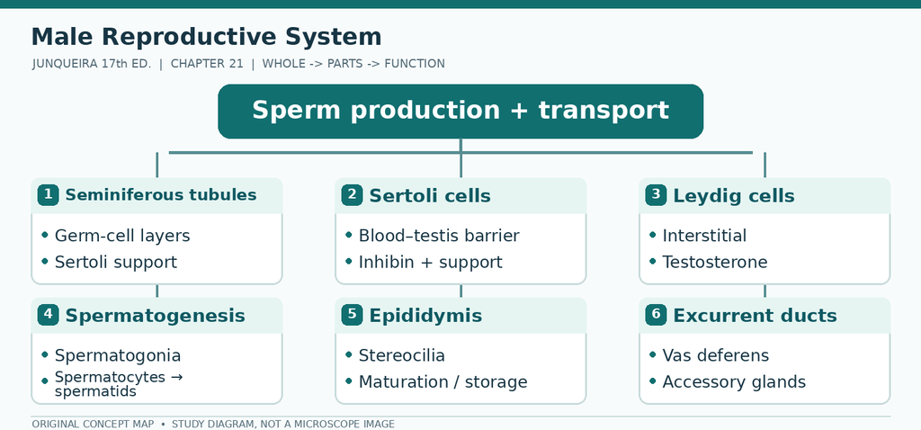

Chapter 21 original concept map: Sperm production + transport; branches for Seminiferous tubules, Sertoli cells, Leydig cells, Spermatogenesis, Epididymis, Excurrent ducts

**Two pathways to remember**

- **Composition:** Spermatogenesis → spermatogonia → primary spermatocytes → spermatids → spermatozoa
- **Progression:** Testis → epididymis → vas deferens → urethra

### Quick notes — understand in 90 seconds

- **Seminiferous tubules:** layers of developing germ cells around Sertoli cells.
- **Sertoli cells:** germ-cell support, blood-testis barrier, inhibin secretion.
- **Leydig cells:** interstitial testosterone-producing endocrine cells.
- **Epididymis:** pseudostratified epithelium with long nonmotile stereocilia.
- **Vas deferens:** thick muscular wall and comparatively smaller folded lumen.

**High-yield comparison:** **Sertoli inside tubules; Leydig between tubules**.

> **MNEMONIC** — Epididymis stereocilia are **actin-based microvilli**, not motile cilia.

**Recall without looking:** Which cell type in the testicular interstitium synthesizes testosterone?

### Learning objectives

By the end of this chapter you should be able to:

1. Describe the compartments of the seminiferous tubule and the blood–testis barrier.
2. Sequence spermatogenesis and spermiogenesis and identify each stage.
3. Trace sperm from tubule to urethra, naming the epithelium at each level.
4. Explain the vascular mechanism of erection and ejaculation.

### The core idea

The testis does two jobs that require opposite conditions: **producing sperm**, which needs a temperature below core (hence the scrotum), and **producing testosterone**, which needs a rich blood supply. The architecture keeps them apart by separating the **seminiferous tubules** from the **interstitium**.

### Testes

- **Tunica albuginea** — thick capsule; the **mediastinum testis** sends septa dividing the gland into about **250 lobules**, each holding **1–4** convoluted seminiferous tubules. Each testis has **250–1000** tubules; each tubule is **150–250 µm** wide and **30–70 cm** long, for a total of about **250 m** per testis.
- **Tunica vaginalis** — the serous sac the testis drags with it during descent: parietal layer lines the scrotum, visceral layer covers the albuginea.
- **Seminiferous tubules** — lined by a **stratified epithelium of germ cells** plus **Sertoli cells**, on a basal lamina, surrounded by **peritubular myoid cells**.
- **Interstitium** — **Leydig cells**, blood vessels, connective tissue.

**Temperature is part of the anatomy.** Sperm formation cannot proceed at 37 °C, so the scrotum holds the testis at about **34 °C** by three mechanisms: evaporation of sweat from scrotal skin; a **countercurrent heat exchanger** in the spermatic cord, where the **pampiniform plexus** of veins cools the incoming testicular artery; and the **dartos** and **cremaster** muscles, which move the testis toward or away from the body.

**Sertoli cells** extend from base to lumen; their nuclei are pale, oval, and have a prominent nucleolus. They are **not** germ-line cells, and each one supports **30–50** developing germ cells. Functions:

- **Physical support and nutrition** of developing germ cells.
- **Blood–testis barrier** — tight junctions between adjacent Sertoli cells near the base, creating basal and adluminal compartments. This is why the immune system does not reject sperm.
- **Phagocytosis** of residual bodies.
- **Secretion** of **androgen-binding protein (ABP)**, **inhibin** (a 39-kDa glycoprotein that suppresses FSH), **Müllerian-inhibiting substance** (MIS, 140 kDa, which regresses the paramesonephric ducts in the fetus), **transferrin**, and fluid that carries sperm out of the testis.
- **Response to FSH** — which acts on Sertoli cells, not on germ cells.

**Spermatogenesis:** **spermatogonia → primary spermatocyte → secondary spermatocyte → spermatid → spermatozoon.** **Meiosis I** halves the chromosome number and **meiosis II** separates chromatids, giving four spermatids per primary spermatocyte. The germ cells do not divide in isolation: cytokinesis is incomplete, so clones stay joined by **cytoplasmic bridges** — a syncytium that lets a haploid cell use products of the full diploid genome, including genes on X or Y. The whole sequence from the last spermatogonial mitosis to spermatid formation takes **about 2 months**, and the testis produces about **200 million sperm per day**.

**Spermiogenesis** is the metamorphosis of a round spermatid into a sperm, and it is conventionally divided into **four phases**:

1. **Golgi phase** — proacrosomal vesicles from the Golgi coalesce into a single **acrosomal cap**; centrioles migrate to the opposite pole and one becomes the basal body of the flagellum.
2. **Cap phase** — the acrosome spreads over about half the nucleus. It is a specialized **lysosome** containing **hyaluronidase** and the trypsin-like protease **acrosin**.
3. **Acrosome phase** — the nucleus condenses and elongates, its histones replaced by **protamines**; a microtubule **manchette** shapes the head; mitochondria gather around the proximal flagellum to form the **middle piece**.
4. **Maturation phase** — excess cytoplasm is shed as a **residual body**, intercellular bridges are lost, and the sperm is released into the lumen.

Because the barrier makes the adluminal compartment immunologically privileged, sperm antigens are not tolerized — which is why vasectomy can produce anti-sperm antibodies.

**Leydig (interstitial) cells** — large, polygonal, **eosinophilic** cells with central nuclei, abundant SER, mitochondria, and lipid droplets, lying singly or in small groups near capillaries. They secrete **testosterone** under **LH**, also called **interstitial cell-stimulating hormone (ICSH)** — the same hormone named LH in females. Fetal Leydig cells are active in the third and fourth months of pregnancy, then become quiescent until puberty.

### Intratesticular Ducts

Sperm leave each tubule through a short **straight tubule**, lined at first only by Sertoli cells and then by simple cuboidal epithelium. It enters the **rete testis**, a labyrinth of cuboidal-lined channels in the mediastinum testis. From there **10–20 efferent ductules** carry sperm to the head of the epididymis.

Their epithelium has a characteristic **scalloped** profile in section — patches of absorptive, nonciliated cuboidal cells with microvilli alternating with patches of taller ciliated cells. Absorption of Sertoli-cell fluid plus ciliary beating creates the flow that moves sperm out of the testis.

### Excretory Genital Ducts

| Segment | Epithelium | Function |
| --- | --- | --- |
| **Epididymis** | **Pseudostratified columnar with stereocilia** | **Maturation and storage of sperm**; about **6 m** long, and transit takes **2–4 weeks** |
| **Ductus (vas) deferens** | Pseudostratified columnar | Transport; **very thick muscular wall** (inner longitudinal, middle circular, outer longitudinal) |
| **Ejaculatory duct** | Columnar | Delivers into the prostatic urethra |

### Accessory Glands

- **Seminal vesicles** — paired, highly tortuous tubes about **15 cm** long, with thin complex mucosal folds and inner circular plus outer longitudinal smooth muscle. Their viscid yellowish secretion makes up about **70%** of the ejaculate and supplies **fructose** (sperm energy), inositol, citrate, **prostaglandins** (which stimulate the female tract), and **fibrinogen** (which lets semen coagulate).
- **Prostate** — a **20-g** organ of **30–50 branched tubuloacinar glands** in a dense **fibromuscular stroma**; **corpora amylacea** are small spherical concretions (up to **2 mm**, partly calcified, made of glycoproteins and keratan sulfate) that become more numerous with age but have no clinical significance. The gland has three zones around the urethra:
  - **Peripheral zone** — about **70%** of the tissue, with the longest ducts; the site of most **carcinomas**.
  - **Central zone** — about **25%**, with submucosal glands.
  - **Transition zone** — about **5%**, with mucosal glands around the upper urethra; the site of **benign prostatic hyperplasia**.
- **Prostate-specific antigen (PSA)** — a **34-kDa serine protease** that liquefies the coagulated ejaculate; it leaks into blood, so a raised serum PSA points to carcinoma or inflammation.
- **Bulbourethral (Cowper) glands** — paired, **3–5 mm** mucous glands in the urogenital diaphragm; their clear secretion lubricates the urethra before ejaculation.

### Penis

Three erectile bodies: two dorsal **corpora cavernosa** and one ventral **corpus spongiosum** containing the urethra and expanding distally as the **glans**. Each is a sponge of **endothelium-lined cavernous spaces** separated by trabeculae of smooth muscle and connective tissue, with a dense **tunica albuginea** around the corpora cavernosa.

Most of the penile urethra is **pseudostratified columnar**, becoming **stratified squamous** in the glans.

Erection is a vascular event with a molecular explanation worth memorizing: parasympathetic acetylcholine makes the endothelium release **nitric oxide**, which activates **guanylate cyclase** and raises **cGMP** in smooth muscle; the muscle relaxes, **helicine arteries** dilate, cavernous spaces fill, and the swollen corpora compress the dorsal veins against the tunica albuginea. **Sildenafil** blocks the phosphodiesterase that degrades cGMP and therefore sustains an erection.

Sympathetic discharge at ejaculation constricts the helicine arteries and trabecular muscle, emptying the spaces.

> **CLINICAL** — **Cryptorchidism** — failure of descent, present in about **4%** of male neonates; most descend in the first year, and bilateral cases cause infertility if not corrected by **2–3 years**. An undescended testis is exposed to core temperature, so spermatogenesis fails and malignancy risk rises. **Hydrocele** — serous fluid in the tunica vaginalis, the commonest cause of scrotal swelling. **Varicocele** — dilation of the pampiniform plexus raises testicular temperature and impairs spermatogenesis. **Prostatic carcinoma** — arises in the peripheral zone, is palpable on rectal examination, and metastasizes to bone. **BPH** — nodular hyperplasia of the transition zone, compressing the urethra. **Testicular tumors** — **95%** are germ-cell tumors, appearing after puberty and more often in untreated cryptorchidism; a painless mass is malignant until proven otherwise.

> **MICRO** — Identify the two compartments instantly. **Inside the tubule: Sertoli cells (pale, tall) and germ cells at various stages.** **Outside the tubule: Leydig cells (eosinophilic, polygonal, in clusters).** If asked for the cell that forms the blood–testis barrier, the answer is Sertoli.

> **TIP** — FSH acts on **Sertoli** cells; LH acts on **Leydig** cells. One sentence, and the two are hard to confuse.

### Chapter 21 — summary

- About 250 lobules per testis, each with 1–4 seminiferous tubules, 150–250 µm wide and 30–70 cm long.
- Spermatogenesis takes about 2 months and yields about 200 million sperm per day.
- Sertoli tight junctions form the blood–testis barrier and divide basal from adluminal compartments.
- Sertoli cells secrete ABP (FSH-dependent), inhibin, MIS, and transferrin, and phagocytose residual bodies.
- Leydig cells secrete testosterone under LH (ICSH).
- Spermiogenesis has four phases: Golgi, cap, acrosome, maturation.
- The acrosome is a lysosome containing hyaluronidase and acrosin; protamines replace histones.
- Straight tubules → rete testis → efferent ductules → epididymis → ductus deferens → ejaculatory duct.
- Seminal vesicles contribute about 70% of semen; the prostate contributes PSA and corpora amylacea.
- Prostate zones: peripheral 70% (cancer), central 25%, transition 5% (BPH).
- Erection is parasympathetic, NO–cGMP mediated; ejaculation is sympathetic.

### Active recall

1. **What forms the blood–testis barrier, and what does it separate?** — Tight junctions between Sertoli cells; basal and adluminal compartments.
2. **Which hormone acts on Sertoli cells, and which on Leydig cells?** — FSH on Sertoli; LH on Leydig.
3. **Name the four phases of spermiogenesis.** — Golgi, cap, acrosome, maturation.
4. **What epithelium lines the epididymis, and what is its hallmark?** — Pseudostratified columnar with stereocilia.
5. **What are corpora amylacea, and where are they found?** — Calcified glycoprotein concretions in prostatic glands.
6. **Which prostatic zone gives rise to cancer, and which to benign hyperplasia?** — Cancer: peripheral (70% of the gland). Benign hyperplasia: transition (5%).
7. **What cools the testicular arterial blood, and how?** — The pampiniform plexus, by countercurrent heat exchange in the spermatic cord.

### Exam-style question

**A 25-year-old man has a painless testicular mass. Which cell type is most likely the origin of a germ-cell tumor?**

A. Leydig cell  
B. Sertoli cell  
C. Spermatogenic cell  
D. Peritubular myoid cell

**Answer: C** — Germ-cell tumors arise from the spermatogenic lineage; Leydig and Sertoli tumors are sex-cord stromal tumors and less common.

### Practical identification

In the testis, identify seminiferous tubules, Sertoli cells, germ cells at each stage, peritubular myoid cells and Leydig cells. Follow sperm from tubule to rete testis, efferent ductules (scalloped epithelium), epididymis (pseudostratified with stereocilia), vas deferens (thick muscle) and prostate (tubuloacinar glands, corpora amylacea). Distinguish the prostatic zones by gland architecture and stroma.

## 22 · The Female Reproductive System

**SPECIALTY EXAM:** `SURGERY`

**In this chapter:** Ovaries · Uterine Tubes · Major Events of Fertilization · Uterus · Embryonic Implantation, Decidua, & the Placenta · Cervix · Vagina · External Genitalia · Mammary Glands

### Chapter mind map — see the whole first

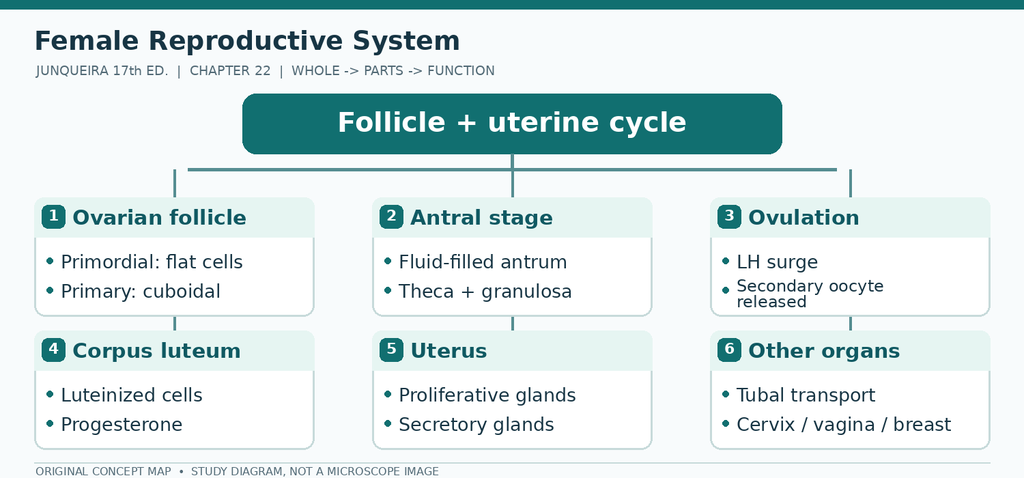

Chapter 22 original concept map: Follicle + uterine cycle; branches for Ovarian follicle, Antral stage, Ovulation, Corpus luteum, Uterus, Other organs

**Two pathways to remember**

- **Composition:** Follicle → primordial → primary → antral → ovulation → corpus luteum
- **Progression:** Uterine cycle → menstrual → proliferative → secretory

### Quick notes — understand in 90 seconds

- **Primordial follicle:** primary oocyte with one layer of flattened follicular cells.
- **Primary follicle:** granulosa cells become cuboidal; zona pellucida develops.
- **Antral follicle:** fluid-filled cavity and organized granulosa/thecal layers.
- **Ovulation:** LH surge; remaining follicle reorganizes as **corpus luteum**.
- **Proliferative endometrium:** relatively straight glands; **secretory:** coiled secretory glands and changing stroma.
- Human polyspermy prevention emphasizes **Ca²⁺-activated cortical granules and zona modifications**.

**High-yield comparison:** **Primordial = flat layer; primary = cuboidal layer; antral = fluid cavity**.

> **MNEMONIC** — Follow the **oocyte, granulosa, theca and antrum** in that order.

**Recall without looking:** What changes in the follicle after ovulation, and which hormone drives that change?

**Visual anchor — simplified schematic:**

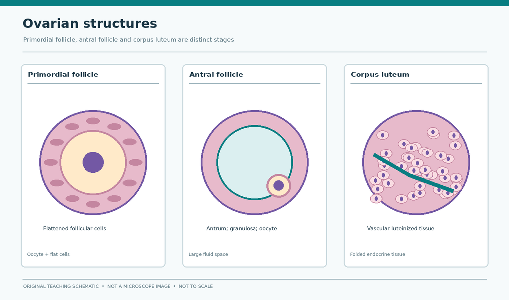

Original schematic of ovarian follicle stages and corpus luteum

### Learning objectives

By the end of this chapter you should be able to:

1. Sequence follicular development from primordial follicle to corpus albicans.
2. Explain the two-cell, two-gonadotropin mechanism of estrogen production.
3. Correlate ovarian and endometrial cycles and identify each phase histologically.
4. Describe implantation, placental structure, and the hormonal control of pregnancy.

### The core idea

The ovary and the endometrium are **rebuilt through a monthly cycle**. Every histological feature of the ovary, tube, uterus, and vagina is a stage in one of two cycles — **ovarian** (follicle to corpus luteum) and **endometrial** (proliferative to secretory) — locked together by the same four hormones.

### Ovaries

Each ovary is an almond-shaped body about **3 cm long, 1.5 cm wide, and 1 cm thick**.

- **Germinal (surface) epithelium** — simple cuboidal mesothelium (a misnomer; it does not produce germ cells).
- **Tunica albuginea** — dense connective tissue.
- **Cortex** — follicles at all stages, plus corpus luteum and corpus albicans.
- **Medulla** — loose connective tissue with the vessels entering at the hilum. Cortex and medulla have no sharp border.

**The oocyte supply is fixed before birth and only falls.** Primordial germ cells reach the gonads in the first month; oogonia peak at about **7 million** in the fifth month of gestation. About **2–2.5 million** primordial follicles are present at birth and about **400,000** at puberty; only about **450** are ovulated in a lifetime, and the rest undergo atresia. Menopause arrives when the reserve falls below about **1000** follicles.

| Stage | Structure | Hormonal influence |
| --- | --- | --- |
| **Primordial follicle** | Oocyte + single layer of flat granulosa cells | None; present from birth |
| **Primary follicle** | Oocyte enlarges (to ~120 µm); granulosa cells become **cuboidal** (unilaminar), then stratified (multilaminar); **zona pellucida** appears | Early growth largely gonadotropin-independent; FSH responsiveness develops |
| **Secondary (antral) follicle** | Antrum forms among the granulosa cells; **theca interna** (steroidogenic, vascular) and **theca externa** (fibrous, contractile) differentiate | FSH and LH |
| **Graafian (mature) follicle** | Single large antrum up to **2 cm**; oocyte on the **cumulus oophorus**, wrapped by the **corona radiata** | LH surge triggers ovulation |
| **Atretic follicle** | Degenerating; **glassy membrane** remains | — |
| **Corpus luteum** | **Granulosa-lutein cells (progesterone, ~80% of the gland)** and **theca-lutein cells (estrogens)** | LH maintains it |
| **Corpus albicans** | White fibrous scar | — |

**The corpus luteum is a temporary gland with two cell populations:**

- **Granulosa-lutein cells** — the old granulosa cells; they enlarge to **20–35 µm** without dividing, make up about **80%** of the gland, and secrete **progesterone** (their SER expands, and they retain some aromatase).
- **Theca-lutein cells** — from the theca interna; about **half the size**, darker staining, lying in the peripheral folds, and secreting **androstenedione** and **estrogens**.

The LH surge sustains progesterone secretion for **10–12 days**. (A common error is to reverse the two populations: the granulosa-lutein cells make progesterone, and the theca-lutein cells make androgens and estrogens.) Without pregnancy, both populations undergo apoptosis, macrophages clear the debris, and fibroblasts lay down a collagen scar — the **corpus albicans**.

Note that **involution is not atresia**: atresia is the death of an unovulated follicle.

**The zona pellucida** is a **5–10 µm** glycoprotein coat between the oocyte and the granulosa cells, secreted by the oocyte. Its glycoproteins **ZP1, ZP2, and ZP3**, all made by the oocyte, form the sperm-binding receptor; binding of a capacitated sperm to this coat begins the acrosomal reaction. In humans the family also includes ZP4.

**Ovulation, step by step.** The LH surge triggers: completion of **meiosis I** with extrusion of the **first polar body**; granulosa production of fluid rich in prostaglandins, proteoglycans, and proteases; **hyaluronan** release that loosens the cumulus; activation of **plasmin**, which digests collagen at the **stigma** (the ischemic bulge on the ovarian surface); and contraction of **theca externa** smooth muscle. The follicle ruptures, releasing the **secondary oocyte, arrested in metaphase II**, wrapped in the **corona radiata** — viable for about **24 hours**. If a sperm arrives, the oocyte completes meiosis II and emits the **second polar body**; the two pronuclei fuse to form the **zygote**.

Junqueira (17th ed.) gives **about 90 days** as an approximate primordial-to-mature follicle interval. This is not a precise timer in humans: estimates depend on stage definitions and methods. Contemporary reviews distinguish gonadotropin-independent early growth, subsequent FSH responsiveness, and later gonadotropin-dependent antral maturation. Usually one dominant follicle ovulates per cycle, whereas most others undergo atresia.

**Two-cell, two-gonadotropin theory:** **LH** stimulates **theca interna** cells to make **androstenedione**; it crosses the basement membrane (the granulosa layer is avascular) and **FSH** stimulates **granulosa** cells to **aromatize** it to **estradiol**. The estrogen returns to the theca capillaries and reaches the whole body. This division of labor explains why both gonadotropins are needed for normal estrogen production — and why the granulosa layer must stay avascular.

### Uterine Tubes

About **10–12 cm** long, in four parts — **infundibulum with fimbriae → ampulla (longest; fertilization happens here) → isthmus → intramural portion**. The mucosa has complex branching folds, tallest in the ampulla, and is lined by **ciliated columnar cells** that sweep fluid toward the uterus and **peg (secretory) cells** that make the nutritive fluid.

The muscularis has interwoven circular and longitudinal layers and provides most of the transport — women with immotile cilia still carry the embryo to the uterus.

### Major Events of Fertilization

Fertilization normally occurs in the **ampulla**, and only a few hundred of the millions of ejaculated sperm reach it. The sequence:

1. **Capacitation** in the female tract makes sperm able to fertilize.
2. The sperm releases **hyaluronidase** to pass between the corona radiata cells.
3. At the zona, binding to the **ZP1–ZP3** complex triggers the **acrosomal reaction**: **acrosin** and other proteases digest a path through the zona.
4. After sperm–oocyte fusion, repeated **intracellular Ca²⁺ rises** trigger **cortical-granule exocytosis**. Released enzymes and factors modify and harden the **zona pellucida**, reducing additional sperm binding and penetration; changes at the egg membrane also contribute to the mammalian block to polyspermy. Rapid electrical depolarization is **not an established fast block in humans** and should not be inferred from observations in some externally fertilizing species.
5. The oocyte completes **meiosis II**, emits the **second polar body**, and forms the female pronucleus; the sperm head decondenses into the male pronucleus. Fusion gives the diploid **zygote**.

Cleavage follows as the embryo travels to the uterus — about **5 days** from fertilization to the blastocyst in the uterine cavity.

### Uterus

The uterus is pear-shaped: **body**, **fundus**, **isthmus**, and **cervix**, with the cervical canal opening at the internal and external os.

- **Perimetrium (serosa)**, **myometrium** (thick smooth muscle in interlacing bundles), **endometrium**.
- **Endometrium** — **stratum functionalis** (shed each month) and **stratum basalis** (retained, regenerates it). The basal layer has a distinctive stroma: fibroblasts, ground substance, **fine type III collagen**, and little or no adipose tissue. **Spiral arteries** supply the functionalis and constrict to cause shedding.

| Phase | Days | Hormone | Histology |
| --- | --- | --- | --- |
| **Menstrual** | 1–4 | Falling progesterone | Shedding, hemorrhage, neutrophilic infiltrate |
| **Proliferative** | 5–14 | **Estrogen** | Glands straight and narrow, mitoses, dense stroma |
| **Secretory** | 15–28 | **Progesterone** | Glands **tortuous and dilated with secretion**, edematous stroma, coiled spiral arteries |

The single best discriminator: **straight, narrow glands = proliferative; saw-toothed, dilated, secreting glands = secretory.**

**Thickness is a second discriminator.** At the end of the proliferative phase the endometrium is **2–3 mm**; in the secretory phase it reaches **5–6 mm**, and the functional layer becomes about **four times** thicker than the basal layer.

**How menstruation happens.** Progesterone and estrogen fall **8–10 days after ovulation**. The spiral arteries contract and relax intermittently, then constrict under local **prostaglandins**, producing ischemia. Hypoxic cells release cytokines that attract leukocytes, whose **collagenases and matrix metalloproteinases** digest the matrix. The functional layer — epithelium, most of each gland, stroma, and blood-filled lacunae — separates from the basal layer and is shed. The basal layer, which does not depend on the spiral arteries, survives and regenerates the next functionalis under estrogen.

### Embryonic Implantation, Decidua, & the Placenta

The blastocyst reaches the uterine cavity about **5 days** after fertilization and floats in the glandular secretion for about **2 days**. Implantation (nidation) takes about **3 days** and is complete by about **day 9**: trophoblast receptors bind glycoproteins on the endometrial epithelium, the **syncytiotrophoblast** digests the stroma, and the embryo embeds.

The trophoblast has two layers — **cytotrophoblast** (mitotic, inner) and **syncytiotrophoblast** (invasive, multinucleated, outer, and the source of **hCG**).

**Chorionic villi** project into maternal blood in the **intervillous space** and develop in three stages: **primary** villi (cytotrophoblast covered by syncytiotrophoblast) about 2 days after implantation; **secondary** villi (mesenchymal cores) about day 15; **tertiary** villi (with capillary loops) a few days later. By the end of the first month there are thousands of tertiary villi.

**Decidua** — the modified endometrium of pregnancy: **decidua basalis** (under the embryo, forms the maternal placenta), **decidua capsularis** (over it), **decidua parietalis** (the rest).

**Placental hormones:** **hCG** (maintains the corpus luteum early; the basis of pregnancy tests), a **lactogen**, **relaxin**, growth factors, progesterone, and estrogen. hCG keeps the corpus luteum of pregnancy alive for **4–5 months**, by which time the placenta itself makes enough progesterone.

### Cervix

The cervix is the lower cylindrical part of the uterus and differs from the body: its mucosa is **2–3 mm** thick, has **no spiral arteries**, and **does not shed** with the cycle.

- **Endocervix** — simple columnar mucus-secreting cells with large branched **cervical glands**.
- **Ectocervix** — **stratified squamous** nonkeratinized epithelium, continuous with the vagina.
- **Transformation zone** — the area just outside the external os where columnar epithelium is replaced by squamous; the site of HPV-related dysplasia and the target of the **Pap smear**.

Cervical mucus changes with hormones: watery and abundant at ovulation (helps sperm), viscous in the luteal phase (hinders them), and a thick **mucus plug** in pregnancy. Before birth, **effacement** dissolves collagen so the cervix softens and dilates.

### Vagina

**Stratified squamous nonkeratinized** epithelium **150–200 µm** thick and rich in **glycogen**, with **no glands** (lubrication comes from cervical and Bartholin glands) and a lamina propria with elastic fibers and venous plexuses. **Lactobacilli** metabolize glycogen to lactic acid, keeping the pH low and protecting against pathogens.

### External Genitalia

The **vulva**: the **labia majora** (skin with hair and sebaceous glands, containing the homologue of the scrotum), **labia minora** (thin skin without hair, with sebaceous glands), the **clitoris** (erectile tissue homologous to the penis), and the **vestibule** containing the urethral and vaginal openings and the openings of the **greater vestibular (Bartholin) glands**, which provide lubrication.

### Mammary Glands

A modified **apocrine sweat gland** whose functional unit is the **terminal duct lobular unit (TDLU)**.

- **Non-lactating** — mostly dense connective tissue and fat with small ducts and lobules.
- **Pregnancy** — lobules proliferate under estrogen and progesterone.
- **Lactation** — alveoli distend with secretion; **protein is released by exocytosis** and **lipid droplets by apocrine secretion**, so milk fat is wrapped in apical plasma membrane. Prolactin drives synthesis, oxytocin the ejection reflex.
- **Duct system** — intralobular → interlobular → **lactiferous ducts** → **lactiferous sinuses** beneath the areola → nipple.

Hormonal control: **estrogen** for ductal growth, **progesterone** for lobuloalveolar development, **prolactin** for milk synthesis, **oxytocin** for milk ejection.

> **CLINICAL** — **Polycystic ovary syndrome** — multiple arrested antral follicles, anovulation, hyperandrogenism. **Endometriosis** — functional endometrial tissue outside the uterus, bleeding cyclically. **Leiomyoma (fibroid)** — a benign smooth-muscle tumor of the myometrium. **Endometrial carcinoma** — unopposed estrogen, with atypical hyperplasia. **Cervical carcinoma** — HPV in the transformation zone. **Ectopic pregnancy** — implantation outside the uterine cavity, usually in the ampulla. **Breast carcinoma** — arises from ductal or lobular epithelium; the **terminal duct lobular unit** is the functional unit to remember.

> **MICRO** — Place the ovary in the cycle by the **dominant structure**: many small primordial follicles = inactive/early; a large antral follicle = late follicular; a corpus luteum with folded, pale, luteinized cells = secretory phase; a hyaline scar = post-ovulatory. In the uterus, look at the **glands**, not the stroma.

> **MNEMONIC** — **“Proliferative = Pencil-thin glands; Secretory = Saw-tooth and swollen.”**

> **COMMON ERROR** — Some summaries reverse the two lutein cell populations, giving estrogen to the granulosa-lutein cells. The correct assignment, and the one that follows from the two-cell mechanism, is **progesterone from the granulosa-lutein cells and estrogens from the theca-lutein cells**.

> **TIP** — The corpus luteum secretes **progesterone**, and it is maintained by **LH** (and, in pregnancy, by **hCG**). Do not say estrogen maintains the corpus luteum.

### Chapter 22 — summary

- Ovary has three regions: cortex with follicles, medulla with vessels, and a surface of **germinal epithelium** over a tunica albuginea.
- Follicle sequence: primordial → primary → secondary (antral) → mature (Graafian) → ovulation.
- **Zona pellucida** = glycoprotein coat around the oocyte; **corona radiata** = granulosa cells carried with it at ovulation.
- **Theca interna** makes androgens; **granulosa cells** aromatize them to estrogen under FSH.
- **Cumulus oophorus** = granulosa mound carrying the oocyte into the antrum.
- After ovulation: **corpus luteum** (progesterone) → **corpus albicans** (hyaline scar).
- Uterine tube: **infundibulum with fimbriae → ampulla → isthmus**; fertilization in the ampulla.
- Endometrium has a **functional layer** that sheds and a **basal layer** that regenerates it.
- Proliferative phase = estrogen, straight narrow glands, mitoses; secretory phase = progesterone, saw-toothed glands, edema.
- Menstrual phase = spiral artery constriction and functionalis shedding.
- Cervix: columnar endocervix, stratified squamous ectocervix, squamocolumnar junction = transformation zone.
- Vagina = stratified squamous nonkeratinized epithelium with glycogen, no glands; acidity comes from lactobacilli.
- Mammary gland: **TDLU** is the functional unit; estrogen drives ducts, progesterone drives lobuloalveolar growth, prolactin drives milk synthesis.

### Active recall

1. **Which cells produce estrogen, and from what precursor?** — Granulosa cells aromatize androgens from theca interna cells.
2. **What is released at ovulation, and at what meiotic stage?** — The secondary oocyte, arrested in metaphase II, with the corona radiata.
3. **What prevents polyspermy?** — Cortical-granule secretion modifies and hardens the zona pellucida; egg-membrane changes also reduce subsequent sperm fusion in mammals.
4. **Which hormone maintains the corpus luteum early in pregnancy?** — hCG.
5. **How do proliferative and secretory endometrium differ?** — Proliferative: straight narrow glands, mitoses. Secretory: tortuous dilated glands with secretion and edematous stroma.

### Exam-style question

**A curettage specimen shows tortuous, saw-toothed glands with secretion and a coiled spiral artery. Which phase is this?**

A. Menstrual  
B. Proliferative  
C. Secretory  
D. Postmenopausal

**Answer: C** — The secretory phase is defined by tortuous secreting glands under progesterone.

### Practical identification

In the ovary, stage the cycle by the dominant follicle or corpus luteum; identify the oocyte, zona pellucida, granulosa, theca interna and externa, and the two lutein cell populations. In the uterus, date the endometrium by gland shape and stromal edema, and identify spiral arteries. In the cervix, find the transformation zone; in the mammary gland, distinguish resting, proliferative and lactating lobules.

**Ovarian-slide staging drill.** A small cortical follicle with a single layer of **flattened follicular cells** is primordial. A growing follicle with a larger oocyte, a zona pellucida and **cuboidal granulosa cells** is primary. A conspicuous fluid-filled **antrum** identifies an antral follicle. After ovulation, a richly vascular folded mass of enlarged steroid-secreting cells identifies a **corpus luteum**.

| Unlabeled sample | Best supporting observation | Most likely identity |
| --- | --- | --- |
| Oocyte beneath one flattened-cell layer | No antrum, very small follicle | Primordial follicle |
| Multiple granulosa layers with a forming fluid cavity | Antrum appears and theca differentiates | Antral (secondary) follicle |
| Large eosinophilic lutein cells in vascular folds | No intact oocyte or follicular antrum | Corpus luteum |
| Endometrial glands are tortuous with luminal secretion | Stromal edema and progesterone effect | Secretory endometrium |

**Microscopy caution.** Small tissue fragments and oblique sections can omit the diagnostic region. A single gland or follicle must not be used as the only basis for assigning an entire organ’s stage.

## 23 · The Eye & Ear: Special Sense Organs

**SPECIALTY EXAM:** `SURGERY`

**In this chapter:** Eyes: The Photoreceptor System · Ears: The Vestibuloauditory System

### Chapter mind map — see the whole first

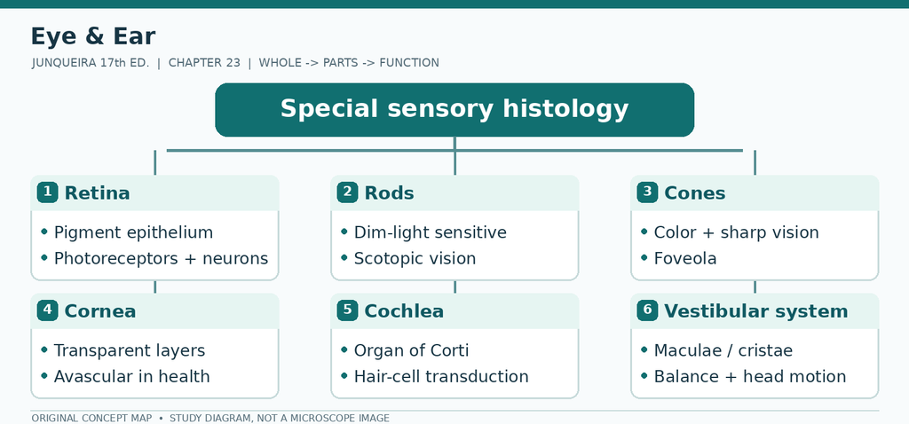

Chapter 23 original concept map: Special sensory histology; branches for Retina, Rods, Cones, Cornea, Cochlea, Vestibular system

**Two pathways to remember**

- **Composition:** Retina → pigment epithelium → rods/cones → bipolar cells → ganglion cells
- **Progression:** Inner ear → cochlea (hearing) + vestibular organs (balance)

### Quick notes — understand in 90 seconds

- **Retina:** neural layers plus retinal pigment epithelium; photoreceptors lie toward its outer side.
- **Rods:** highly light-sensitive, support dim-light vision.
- **Cones:** color and high-acuity vision; concentrated at the foveola.
- **Cornea:** transparent layered tissue, avascular in health.
- **Cochlea:** organ of Corti with inner and outer hair cells for hearing.
- **Vestibular apparatus:** hair cells detect position and head movement.

**High-yield comparison:** **Rods = dim-light sensitivity; cones = high-acuity/color vision**.

> **MNEMONIC** — A retinal label must specify **which side faces the pigment epithelium**.

**Recall without looking:** Where are photoreceptor nuclei found in the retinal layers?

### Learning objectives

By the end of this chapter you should be able to:

1. Name the three tunics of the eye and the five layers of the cornea.
2. Trace aqueous humor and explain glaucoma.
3. Describe the layers of the retina and the path of a light signal.
4. Compare the vestibular and cochlear sensory epithelia and their transduction mechanisms.

### The core idea

Both organs convert a physical signal into a nerve impulse through a **specialized epithelium** — the retina for light, the organ of Corti for sound. Their histology is therefore about **transduction**, not merely structure.

**Numbers to anchor the chapter:** the adult eyeball is about **22 mm** in diameter; the **sclera** is 0.5 mm thick (1 mm posteriorly); the **cornea** is the anterior one-sixth and is **avascular**; the retina has **nine neural layers plus a pigmented layer**; the cochlea is about **35 mm** long with **2¾ turns**.

### Eyes: The Photoreceptor System

**Three tunics:**

| Tunic | Components | Function |
| --- | --- | --- |
| **Fibrous** | **Cornea** and **sclera** | Protection and support; the cornea also refracts |
| **Vascular (uvea)** | **Choroid, ciliary body, iris** | Nutrition, accommodation, pupil control |
| **Nervous** | **Retina** | Phototransduction |

**The cornea has five layers**, and the order is a standard question:

1. **Corneal epithelium** — stratified squamous, nonkeratinized, **5–6 cells thick**, about **10%** of corneal thickness; its stem cells sit in the **limbus**, and it has one of the richest sensory innervations in the body.
2. **Bowman’s membrane** — a thick (**8–10 µm**) basement membrane.
3. **Stroma** — about **90%** of the thickness, some **60 layers** of type I collagen at right angles to each other, with flattened **keratocytes** between them; **avascular**.
4. **Descemet’s membrane** — the thick basement membrane of the endothelium.
5. **Corneal endothelium** — simple squamous, the most metabolically active cells of the cornea; their **Na⁺/K⁺ ATPase** pumps control stromal hydration and therefore transparency.

The cornea is **transparent because it is avascular and its collagen is regularly arranged**. When it becomes edematous or scarred, it loses transparency — the anatomical explanation for corneal blindness.

- **Choroid** — pigmented, vascular; two layers: the inner **choroidocapillary lamina** (nourishes the outer retina) and **Bruch’s membrane**, an elastin sheet between two collagen layers, next to the retinal pigment epithelium.
- **Ciliary body** — **ciliary muscle** (fibers in three complementary orientations; accommodation) and numerous **ciliary processes** covered by a **bilaminar epithelium**: a pigmented layer next to the stroma and a nonpigmented superficial layer. The nonpigmented cells pump aqueous humor and also secrete the **fibrillin** microfibrils of the **ciliary zonule** that suspends the lens.
- **Iris** — a stroma with melanocytes and, posteriorly, two pigmented epithelial layers. The anterior surface has **no epithelium**, only fibroblasts and melanocytes. The **dilator pupillae** is a layer of **myoepithelial cells** (sympathetic); the **sphincter pupillae** is a circular smooth-muscle bundle near the pupil (parasympathetic).

**Aqueous humor** is secreted by the ciliary processes into the **posterior chamber**, flows through the **pupil** into the **anterior chamber**, and drains at the **iridocorneal angle** through the **trabecular meshwork** into the **scleral venous sinus (canal of Schlemm)**, then into scleral veins. It has the ions of plasma but almost no protein. Blockage raises intraocular pressure — **glaucoma**; a narrow angle that closes when the pupil dilates gives **angle-closure glaucoma**.

**The lens:** **capsule** (10–20 µm, type IV collagen and proteoglycans) → **subcapsular epithelium** (simple cuboidal, anterior surface only) → **lens fibers** (7–10 mm long, 2 × 8 µm in cross-section, packed with **crystallins**, their organelles and nuclei removed by autophagy). New fibers are added at the equator throughout life, so the lens grows and its nucleus becomes denser. It is **avascular** and suspended by the zonule.

**Accommodation:** at rest the ciliary muscle is relaxed, the zonule is taut, and the lens is **flat** for distant vision. To focus close, the ciliary muscle **contracts**, the ciliary body moves forward, tension on the zonule falls, and the lens becomes **rounder**. Loss of lens elasticity in the fourth decade is **presbyopia**; loss of transparency is **cataract**.

**The retina** — the neural retina has **nine layers**, and with the pigment epithelium there are ten. From the vitreous inward-outward (following the path of light): **inner limiting membrane → nerve fiber layer → ganglion cell layer → inner plexiform layer → inner nuclear layer → outer plexiform layer → outer nuclear layer → outer limiting layer → rod and cone layer → pigmented layer.**

| Layer | Contents |
| --- | --- |
| **Retinal pigment epithelium (RPE)** | Cuboidal, pigmented; absorbs stray light, forms the **blood–retina barrier** with tight junctions, **phagocytoses shed rod discs**, regenerates **11-cis-retinal**, and secretes trophic factors |
| **Photoreceptor layer** | **Rods** (rhodopsin, dim light, ~92 million) and **cones** (iodopsin, color, ~4.6 million). Rod discs are **membrane stacks**; cone outer segments are **conical**. |
| **Outer nuclear layer** | Photoreceptor nuclei |
| **Inner nuclear layer** | Bipolar, horizontal, amacrine, and Müller cell nuclei |
| **Ganglion cell layer** | Ganglion cells whose axons form the optic nerve |

**Rods versus cones at the level of the disc** — a classic distinction: in **cones** the membranous discs of the outer segment are **continuous with the plasma membrane**; in **rods** they are **separate**, pinched-off discs. A single rod contains about **one billion rhodopsin** molecules, and each day it loses and replaces about **90 discs** in a cycle that takes **10 days**.

**Phototransduction in one paragraph.** In darkness, cGMP keeps **cGMP-gated Na⁺ channels** open, so the photoreceptor is depolarized and steadily releases **glutamate**. A photon isomerizes **11-cis-retinal** to **all-trans-retinal** within a picosecond; the opsin changes shape and activates **transducin**, a heterotrimeric G protein whose α subunit stimulates **phosphodiesterase** to hydrolyze cGMP. The channels close, the cell **hyperpolarizes**, and transmitter release falls — which **depolarizes** the bipolar cells and sends signals to the ganglion cells. The free all-trans-retinal is carried to the RPE, re-isomerized to 11-cis, and returned; this **bleaching** cycle takes a minute or more and underlies slow dark adaptation.

The retina is **inverted**: light passes through the ganglion cell and inner layers before reaching the photoreceptors, which sit against the pigment epithelium. The **fovea centralis**, within the **macula lutea**, has an exceptionally high central cone density.

Its **central foveola** is rod-free, while a few rods can occur toward the peripheral fovea; inner retinal layers are displaced laterally, improving light access to the central cones. That is why acuity is highest there, but only in good light. The **optic disc** is the **blind spot**: ganglion-cell axons converge there to form the optic nerve, and photoreceptors are absent.

**Müller cells** are the principal glia — modified astrocytes whose cell bodies lie in the inner nuclear layer and whose processes span the whole retina. They provide trophic support, buffer ions and water, regulate blood flow, form the **inner limiting membrane**, and join photoreceptors by zonulae adherentes to form the **outer limiting layer**.

### Ears: The Vestibuloauditory System

**External ear** — the **auricle** is a plate of **elastic cartilage** covered by tightly adherent skin; the **external acoustic meatus** is lined by skin with hairs, sebaceous glands, and modified apocrine **ceruminous glands**. Their product, **cerumen**, contains proteins, saturated fatty acids, and shed keratinocytes and is antimicrobial. Elastic cartilage supports the outer third of the meatus; the temporal bone encloses the inner part. The **tympanic membrane** is fibroelastic connective tissue covered by epidermis outside and simple cuboidal mucosa inside.

**Middle ear** — an air-filled **tympanic cavity** lined by simple cuboidal epithelium, containing the **ossicles** (malleus, incus, stapes) linked by synovial joints, with two small muscles (**tensor tympani** on the malleus, **stapedius** on the stapes) that damp loud sounds. The **auditory (eustachian) tube** connects to the pharynx and equalizes pressure; the **oval window** receives the stapes and the **round window** relieves the pressure wave.

**Inner ear** — **bony labyrinth** containing the membranous labyrinth:

- **Cochlea** — a **35-mm** canal with **2¾ turns** around a bony core, the **modiolus**. It has three compartments: **scala vestibuli** (perilymph) above, **scala media / cochlear duct** (endolymph) in the middle, and **scala tympani** (perilymph) below. Vestibuli and tympani communicate at the apex through the **helicotrema**. The **vestibular (Reissner) membrane** separates vestibuli from media with tight junctions that keep the two fluids apart; the **basilar membrane** separates media from tympani.
- The **organ of Corti** sits on the basilar membrane: **about 12,000 outer hair cells in three rows (five near the apex)** with V-shaped stereocilia bundles, and a **single row of inner hair cells** with a linear bundle. The inner row is far more heavily innervated. **Phalangeal cells** support the hair cells and, with them, form the **apical plate**; **pillar cells** enclose the stiff **inner tunnel**. The tallest stereocilia of the outer cells are embedded in the acellular **tectorial membrane** (collagens II, V, and IX, proteoglycans, and tectorin).
- The **stria vascularis** in the lateral wall secretes endolymph, pumping K⁺ into the lumen.
- **Vestibule** — **utricle** and **saccule**, each with a **macula** containing hair cells and otoliths (gravity and linear acceleration).
- **Semicircular canals** — **cristae ampullares** with hair cells in a cupula (rotational acceleration).

**Endolymph** fills the membranous labyrinth: **K⁺ about 150 mM, Na⁺ about 16 mM** — like intracellular fluid, and the source of the driving force for transduction. **Perilymph** fills the bony labyrinth and resembles cerebrospinal fluid. Perilymph drains through the perilymphatic duct to the subarachnoid space; endolymph drains through the endolymphatic duct to dural venous sinuses.

**Transduction** is the same in the macula, crista, and organ of Corti: bending the stereocilia toward the tallest opens **mechanically gated K⁺ channels**, K⁺ enters, the cell depolarizes, voltage-gated Ca²⁺ channels open at the base, and transmitter release rises. Bending the other way closes the channels and silences the cell.

> **CLINICAL** — **Glaucoma** — raised intraocular pressure from impaired drainage through the trabecular meshwork, damaging the optic nerve. **Cataract** — lens opacity from crystallin denaturation. **Age-related macular degeneration** — degeneration of the RPE and photoreceptors at the macula. **Retinal detachment** — separation of the neural retina from the RPE, which starves the photoreceptors. **Diabetic retinopathy** — microvascular damage with hemorrhage and neovascularization. **Otosclerosis** — ossification of the stapes footplate, producing conductive deafness. **Presbycusis** — age-related loss of hair cells and neurons. **Ménière disease** — endolymphatic hydrops with vertigo, tinnitus, and fluctuating deafness.

**Eyelids and tear film** — the inner surface of the eyelid and the anterior sclera are covered by **conjunctiva**, a **stratified columnar epithelium with goblet cells** that is continuous with the corneal epithelium. **Lacrimal glands** produce the tear film, which drains through the lacrimal apparatus into the nasal cavity.

> **MICRO** — The **cornea** is identified by five layers and a regular, avascular stroma. The **retina** by its ten layers with a pigmented layer at the outer border and ganglion cells at the inner border. The **organ of Corti** by the tunnel of Corti between inner and outer hair cells on the basilar membrane, with the tectorial membrane above.

> **TIP** — Rods detect **dim light**, cones detect **color and detail**; the **central foveola contains only cones**, helping explain peak visual acuity; rod density increases outside the foveal center.

### Chapter 23 — summary

- The eyeball is about 22 mm; the sclera is 0.5 mm thick (1 mm posteriorly).
- Cornea: epithelium, Bowman membrane, stroma, Descemet membrane, endothelium — avascular and transparent.
- Aqueous humor: ciliary processes → posterior chamber → pupil → anterior chamber → trabecular meshwork → canal of Schlemm.
- The lens is avascular, suspended by the fibrillin zonule; it becomes rounder when the ciliary muscle contracts.
- The retina has nine neural layers plus the pigmented epithelium.
- Rods support scotopic vision and cones support high-acuity color vision; the **foveola** is rod-free, whereas the wider fovea can contain peripheral rods. Total photoreceptor counts vary among individuals and measurement methods.
- Phototransduction: retinal isomerization → transducin → phosphodiesterase → cGMP falls → channels close → hyperpolarization.
- The RPE absorbs light, forms the blood–retina barrier, phagocytoses discs, and regenerates 11-cis-retinal.
- Endolymph is high-K⁺; perilymph resembles CSF.
- Organ of Corti: about 12,000 outer hair cells in 3–5 rows and a single row of inner hair cells.
- Maculae sense gravity and linear acceleration; cristae sense rotation; the cochlea hears.

### Active recall

1. **Name the five layers of the cornea, outside in.** — Epithelium, Bowman membrane, stroma, Descemet membrane, endothelium.
2. **Where is aqueous humor produced and where does it drain?** — Ciliary processes; drains through the trabecular meshwork into the canal of Schlemm.
3. **Which retinal cells form the optic nerve?** — Ganglion cells.
4. **Why is acuity highest in the central foveola?** — Its densely packed cones and laterally displaced inner retinal layers support precise, minimally obstructed sampling of the retinal image.
5. **Endolymph versus perilymph?** — Endolymph (high K⁺) fills the membranous labyrinth; perilymph (high Na⁺) fills the bony labyrinth.

### Exam-style question

**A patient loses vision from increased intraocular pressure. Where is the obstruction?**

A. Ciliary processes  
B. Pupil  
C. Trabecular meshwork and canal of Schlemm  
D. Central retinal artery

**Answer: C** — Glaucoma results when aqueous humor cannot drain through the trabecular meshwork into the canal of Schlemm.

### Practical identification

In the eye, identify the five corneal layers, the sclera, choroid, ciliary body with its bilaminar epithelium, iris, lens and the ten retinal layers. Locate the fovea and optic disc and explain the differences in photoreceptor density. In the ear, identify the three cochlear compartments, the organ of Corti with inner and outer hair cells, the tectorial and basilar membranes, and the cristae and maculae.

# PART VI — RAPID REVIEW AND REFERENCE

## 24 · The Last-24-Hours Rapid Review

> **PEARL** — This chapter is designed to be read in one sitting, twice. Read it once slowly, then again out loud. Everything in it is either a rule that generates other facts or a fact worth being able to state from memory.

### The subject as a concept map

If you remember nothing else, remember the shape of the subject. Each level is generated by the level above it, and each arrow is a question the subject naturally poses.

- **Molecules** — proteins, lipids, carbohydrates, nucleic acids
  - **Organelles** — membrane, cytosol, nucleus (Chapters 2–3)
    - **Cells** — each specialized by which organelle it expands
      - **Epithelium** — sits on a basal lamina, avascular, joined by junctions (Chapter 4)
        - **Surface epithelium** — number of layers and shape of the top cell
        - **Glandular epithelium** — merocrine, apocrine, holocrine
      - **Connective tissue** — defined by its matrix (Chapter 5)
        - **Loose / dense / reticular / elastic / adipose** — amount and arrangement of fibers
        - **Cartilage and bone** — matrix stiffened by proteoglycan or mineral (Chapters 7–8)
      - **Muscle** — converts ATP into movement (Chapter 10)
        - **Skeletal** — voluntary, peripheral nuclei, triads at the A–I junction
        - **Cardiac** — branched, central nucleus, intercalated discs, diads at the Z line
        - **Smooth** — no striations, calmodulin, dense bodies
      - **Nervous tissue** — converts stimulus into impulse (Chapter 9)
        - **Neuron** — soma, dendrites, axon, synapse
        - **Glia** — oligodendrocyte, Schwann, astrocyte, microglia, ependyma
  - **Organs** — one tissue arrangement plus a supporting stroma
    - **Tubes** — concentric layers (gut, vessels, ducts, ureter)
    - **Solid organs** — capsule, cortex, medulla, hilum (kidney, ovary, lymph node)
    - **Glands** — ducts or no ducts (exocrine versus endocrine)
  - **Systems** — organs that share a transport medium
    - **Circulatory** — heart, vessels, blood, lymph (Chapters 11–13)
    - **Immune** — thymus, lymph node, spleen, MALT (Chapter 14)
    - **Digestive** — gut tube plus liver, pancreas, salivary glands (Chapters 15–16)
    - **Respiratory** — conducting airway plus alveoli (Chapter 17)
    - **Integumentary** — skin and appendages (Chapter 18)
    - **Urinary** — filtration, reabsorption, storage (Chapter 19)
    - **Endocrine** — pituitary, thyroid, adrenal, islets, parathyroid, pineal (Chapter 20)
    - **Reproductive** — testis and ovary, then ducts and glands (Chapters 21–22)
    - **Special senses** — eye and ear (Chapter 23)

> **PEARL** — Read the map downward when you revise a chapter, and upward when you face an unknown slide. Downward gives you the function; upward gives you the name.

### The 60-second organ identification algorithm

**Step 1 — Is there a lumen?** - **No obvious large lumen** → look for follicles, cords, sinusoids, lobules or lymphoid tissue. Small ducts and vessels may still be present; lack of a visible lumen does not establish that an organ is solid. - **Yes, a lumen** → go to Step 2.

**Step 2 — What is the epithelium?** - **Stratified squamous** → esophagus, oral cavity, vagina, anal canal, epidermis (no lumen). - **Simple columnar epithelium** → assess surface architecture: gastric pits in stomach; villi and intestinal crypts in small intestine; straight crypts without villi in colon; folds without true intestinal crypts in gallbladder or uterine tube. - **Pseudostratified ciliated** → respiratory tract. **Pseudostratified with stereocilia** → epididymis, vas deferens. - **Transitional** → ureter, bladder, renal pelvis. - **Simple cuboidal/columnar tubules** → kidney, salivary ducts, epididymis.

**Step 3 — What surrounds it?** - **Cartilage rings** → trachea. **Cartilage plates** → bronchus. **No cartilage** → bronchiole. - **Three muscle layers** → stomach. **Taeniae coli** → colon. **Thick muscle wall** → vas deferens, ureter. - **Serosa** indicates a mesothelial covering; **adventitia** indicates attachment to surrounding connective tissue. These coverings depend on the organ segment and cannot alone determine its peritoneal position.

### How to Read an Unfamiliar Histology Slide Without Guessing

**First pass: orientation (low power).** Decide whether you are looking at a hollow organ, a solid organ, a sheet of tissue, or a mixed specimen. Look for the boundary of the sample, connective-tissue septa, major vessels, a capsule if present, and any recognizable lumen. A single section may cut an organ obliquely, and a biopsy may omit diagnostic landmarks.

**Second pass: tissue architecture (medium power).** Identify epithelial layers, glands, follicles, ducts, tubules, muscle bundles, vascular channels, lymphoid aggregates and extracellular matrix. Ask which components repeat and how they are organized. For hollow organs, follow the wall from lumen outward; for solid organs, identify functional units rather than assuming every organ has a cortex and medulla.

**Third pass: cellular evidence (high power).** Compare nuclear shape, cytoplasmic staining, apical specialization, granules, extracellular fibers and cell arrangement. Recognize artifacts: folds may mimic thick epithelium, shrinkage can create false spaces, and tangential sections can make one layer look like several.

**Fourth pass: test alternatives.** State at least two observations that support your identification and one finding that would favor a competing organ. For example, both small intestine and colon have intestinal crypts, but villi strongly favor small intestine; Brunner glands in the submucosa support duodenum.

**Fifth pass: communicate uncertainty.** If the distinguishing feature is absent, identify the tissue at the highest defensible level (for example, *intestinal mucosa* rather than *ileum*). A confident but unsupported organ label is less useful than an accurate description.

**Practice case A.** You see simple columnar epithelium with many goblet cells, closely packed straight crypts and no villi. What is the best identification? **Answer:** colonic-type mucosa. The absence of villi and abundance of goblet-rich straight crypts favor large intestine; the precise segment may require additional landmarks.

**Practice case B.** You see a tube lined by urothelium with mucosal folds and a thick, irregular smooth-muscle wall. What alternatives remain? **Answer:** ureter and urinary bladder. A relatively small, stellate lumen and organized muscular layers favor ureter; a broad lumen and interlacing detrusor bundles favor bladder, but section orientation matters.

**Practice case C.** You see densely packed tubules and scattered round capillary tufts surrounded by a narrow space. What tissue is present? **Answer:** renal cortex, because renal corpuscles are present. Proximal and distal tubules should then be distinguished by their apical brush borders and staining patterns.

**Retrieval rule:** cover each answer and justify your choice from the visual evidence before reading the explanation. The purpose is to learn an observable decision process, not to memorize an organ name from a single photograph.

### The ten master tables

**1. Epithelium by location**

| Epithelium | Where |
| --- | --- |
| Simple squamous | Alveoli, endothelium, mesothelium, Bowman capsule |
| Simple cuboidal | Kidney tubules, thyroid follicles, small ducts, ovary surface |
| Simple columnar | Stomach, intestine, gallbladder, uterine tube |
| Pseudostratified ciliated | Trachea, bronchi, nasal cavity |
| Pseudostratified with stereocilia | Epididymis, vas deferens |
| Stratified squamous keratinized | Epidermis |
| Stratified squamous non-keratinized | Oral cavity, esophagus, vagina, cornea, anal canal |
| Transitional | Renal pelvis, ureter, bladder, proximal urethra |
| Epithelioid | Adrenal cortex, islets, liver |

**2. Collagen types**

| Type | Where | Disease |
| --- | --- | --- |
| I | Bone, skin, tendon, cornea | Osteogenesis imperfecta |
| II | Cartilage, vitreous | Chondrodysplasia |
| III | Reticulin: lymphoid organs, marrow, liver | Ehlers–Danlos vascular |
| IV | Basement membrane | Alport syndrome |
| V | Cornea, bone, placenta | Ehlers–Danlos |

**3. Muscle**

| Feature | Skeletal | Cardiac | Smooth |
| --- | --- | --- | --- |
| Striations | Yes | Yes | **No** |
| Nuclei | Many, **peripheral** | 1–2, **central** | 1, **central** |
| Junctions | — | **Intercalated discs** | Gap junctions |
| T-tubules | Triads at A–I | Diads at Z | Caveolae |
| Ca²⁺ sensor | Troponin C | Troponin C | **Calmodulin** |
| Regeneration | Limited, supported by satellite cells | Very limited in adults; clinically insufficient after major injury | Hypertrophy and, in some settings, hyperplasia |

**4. Cartilage**

| Feature | Hyaline | Elastic | Fibrocartilage |
| --- | --- | --- | --- |
| Collagen | II | II + elastic | **I + II** |
| Perichondrium | Yes | Yes | **No** |
| Where | Trachea, ribs, joints, nose | Epiglottis, pinna | Disc, symphysis, menisci |
| Cells | Isogenous groups | Numerous | **Rows** |

**5. Bone cells**

| Cell | Origin | Job |
| --- | --- | --- |
| Osteoprogenitor | Mesenchyme | Precursor |
| Osteoblast | Mesenchyme | **Make osteoid**, RANKL |
| Osteocyte | Osteoblast | Maintain, sense load |
| Osteoclast | Fusion of monocyte/macrophage-lineage precursors | **Resorb**, ruffled border |

**6. Blood cells**

| Cell | % | Nucleus | Signature |
| --- | --- | --- | --- |
| Neutrophil | 50–70 | 3–5 lobes | Pale granules |
| Eosinophil | 1–4 | **Bilobed** | **Orange-red** granules |
| Basophil | 0.5–1 | S-shaped, hidden | Dark blue granules |
| Lymphocyte | 20–40 | Round, dense | Scant cytoplasm |
| Monocyte | 2–8 | **Kidney-shaped** | Largest cell |

**7. Lymphoid organs**

| Organ | Follicles | Afferent lymph | Unique |
| --- | --- | --- | --- |
| Thymus | **No** | No | **Hassall corpuscles** |
| Lymph node | Yes | **Yes** | Cortex/paracortex/medulla |
| Spleen | Yes | **No** | White + red pulp |
| Tonsil | Yes | No | Crypts, partial capsule |

**8. Gut segments**

| Segment | Diagnostic feature |
| --- | --- |
| Esophagus | Stratified squamous, skeletal muscle above |
| Stomach | **Three muscle layers**, parietal + chief cells, no goblet |
| Duodenum | **Brunner glands (submucosa)** |
| Jejunum | Tallest villi; no Brunner glands; Peyer’s patches belong to the ileum |
| Ileum | **Peyer’s patches** |
| Colon | **No villi**, crypts, many goblet, taeniae |
| Appendix | Lymphoid tissue all round, blind tube |

**9. Endocrine**

| Gland | Pattern | Hormone |
| --- | --- | --- |
| Thyroid | **Follicles with colloid** | T3, T4; C cells → calcitonin |
| Parathyroid | Cords of chief cells | PTH |
| Adrenal cortex G/F/R | Cords | Aldosterone / cortisol / androgens |
| Adrenal medulla | Chromaffin | Epinephrine |
| Pituitary anterior | Acidophils + basophils | GH, PRL / ACTH, TSH, FSH, LH |
| Pituitary posterior | Fibrillary, Herring bodies | Oxytocin, ADH |
| Islets | Clusters | Insulin, glucagon, somatostatin |

**10. Airway**

| Level | Cartilage | Glands | Muscle |
| --- | --- | --- | --- |
| Trachea | **Rings** | Yes | Trachealis |
| Bronchus | **Plates** | Yes | Complete ring |
| Bronchiole | **None** | **None** | Prominent |
| Respiratory bronchiole | None | None | + alveoli in wall |

### One hundred facts in one hundred lines

1. Basophilic = binds hematoxylin = nucleic acid.
2. Eosinophilic = binds eosin = protein.
3. PAS stains glycogen and basement membrane.
4. Silver stains reticulin (type III collagen).
5. Light microscope resolution = 0.2 µm.
6. Frozen section = rapid diagnosis + lipid preservation.
7. Plasma membrane thickness = 7.5–10 nm.
8. Na⁺/K⁺-ATPase pumps 3 Na⁺ out, 2 K⁺ in.
9. Clathrin mediates receptor-mediated endocytosis.
10. Mitochondria are maternally inherited.
11. Steroid-secreting cells have **tubular** cristae.
12. Nissl bodies = rough ER + polysomes.
13. Golgi **modifies and sorts**; RER **synthesizes**.
14. Lysosomes are acidic (pH ≈ 5).
15. Lipofuscin = residual body pigment.
16. Peroxisomes contain catalase.
17. Proteasomes degrade ubiquitin-tagged protein.
18. Kinesin = anterograde; dynein = retrograde.
19. Conventional motile epithelial cilium = 9 + 2 doublet-based axoneme; primary sensory cilium usually = 9 + 0 doublet-based axoneme; basal body = nine microtubule triplets.
20. Keratin = epithelium; vimentin = mesenchyme; desmin = muscle; GFAP = astrocyte.
21. Lamin A mutation = progeria.
22. Nucleolus makes rRNA; NORs on 13, 14, 15, 21, 22.
23. Barr body = inactivated X.
24. p53 = guardian of the genome.
25. Meiosis = four haploid cells; crossing over in pachytene.
26. Apoptosis = no inflammation.
27. Labile tissue = epidermis, gut, marrow; permanent = neurons, cardiac muscle.
28. Epithelium is avascular.
29. Basal lamina = lamina lucida + lamina densa; the basement membrane adds the reticular lamina (type III collagen).
30. Type IV collagen is in the basal lamina.
31. Desmosomes link to keratin; hemidesmosomes to laminin via integrin.
32. E-cadherin is calcium-dependent.
33. Gap junctions = connexins.
34. Microvilli core = actin.
35. Stereocilia are long microvilli (epididymis).
36. Endothelium and mesothelium are simple squamous.
37. Pseudostratified epithelium is truly one layer.
38. Transitional epithelium has umbrella cells and uroplakins.
39. Goblet cell = unicellular mucous gland.
40. Sebaceous gland = holocrine.
41. Mammary gland = modified apocrine gland; lipid by apocrine secretion, protein by merocrine secretion.
42. Pancreas = merocrine.
43. Myoepithelial cells compress acini.
44. Collagen synthesis needs **vitamin C** and **copper**.
45. Scurvy = defective hydroxylation.
46. Marfan = fibrillin.
47. Ehlers–Danlos = collagen processing.
48. Plasma cell nucleus = clock-face, eccentric.
49. Mast cell = histamine + heparin.
50. Brown fat = multilocular + UCP1 + central nucleus.
51. Leptin reduces appetite; adiponectin increases insulin sensitivity.
52. Hyaline cartilage = type II collagen.
53. Fibrocartilage = **no perichondrium**.
54. Interstitial growth = from within lacunae.
55. Osteoclast = monocyte lineage, TRAP-positive.
56. Osteoblast = RANKL; OPG is the decoy.
57. Osteon = concentric lamellae + Haversian canal.
58. Epiphyseal zones: reserve → proliferate → hypertrophy → calcify → ossify.
59. Intramembranous ossification = flat bones.
60. PTH raises calcium; calcitonin lowers it.
61. Oligodendrocyte = CNS, many axons; Schwann = PNS, one segment.
62. Microglia are mesodermal.
63. Wallerian degeneration occurs distal to injury.
64. Regeneration ≈ 1 mm/day.
65. A band never shortens.
66. Skeletal T-tubules form triads at the A–I junction.
67. Cardiac T-tubules form diads at the Z line.
68. Smooth muscle uses calmodulin, not troponin.
69. Intercalated discs = fascia adherens + desmosome + gap junction.
70. Purkinje fibers conduct; they are not neurons.
71. Elastic artery = elastic lamellae in media.
72. Muscular artery = prominent internal elastic lamina.
73. Sinusoidal capillaries = liver, spleen, marrow.
74. Blood–brain barrier = continuous capillaries + tight junctions.
75. Lymphatic capillaries are blind-ended.
76. Erythrocyte lifespan = 120 days.
77. Neutrophil = 3–5 lobes, acute inflammation.
78. Eosinophil = parasites and allergy.
79. Basophil = histamine, IgE.
80. Monocyte = largest leukocyte.
81. Platelets = 2–4 µm, from megakaryocytes.
82. EPO from kidney; TPO from liver.
83. M:E ratio = 2:1 to 4:1.
84. CD4 ↔︎ MHC II; CD8 ↔︎ MHC I.
85. Thymus has no follicles; spleen has no afferent lymphatics.
86. Hassall corpuscles = thymus.
87. PALS = T-cell zone of spleen.
88. Germinal center = B-cell proliferation.
89. Enteric plexuses: Meissner (submucosa), Auerbach (myenteric).
90. Parietal cell = HCl + intrinsic factor.
91. Chief cell = pepsinogen.
92. Paneth cell = lysozyme and defensins.
93. Brunner glands = duodenum.
94. Peyer’s patches = ileum.
95. Portal triad = artery, portal vein, bile duct.
96. Bile flows toward the triad; blood flows away.
97. Type I pneumocyte = gas exchange; type II = surfactant.
98. Club (formerly Clara) cells = bronchioles; they secrete surfactant-like material and detoxify inhaled compounds.
99. Podocytes form the filtration slit diaphragm (nephrin).
100. Macula densa = distal tubule; JG cells = afferent arteriole.

### Twenty-five distinctions worth knowing

| Do not confuse | With | The difference |
| --- | --- | --- |
| Basophilic | Eosinophilic | DNA/RNA versus protein |
| Mucous | Mucosa | Secretion versus lining layer |
| Endothelium | Mesothelium | Vessels versus body cavities |
| Pseudostratified | Stratified | One layer versus many |
| Hyaline cartilage | Fibrocartilage | Type II + perichondrium versus I + II + none |
| Osteoblast | Osteoclast | Builds versus resorbs; mesenchymal versus monocyte |
| Astrocyte | Oligodendrocyte | Support/BBB versus myelination |
| Schwann cell | Oligodendrocyte | One segment versus many axons |
| Neutrophil | Eosinophil | 3–5 lobes versus bilobed |
| Monocyte | Lymphocyte | Kidney-shaped versus round |
| Proximal tubule | Distal tubule | Brush border, eosinophilic versus clean, pale |
| Type I pneumocyte | Type II | Thin for gas versus cuboidal for surfactant |
| Parietal cell | Chief cell | HCl versus pepsinogen |
| Brunner gland | Peyer’s patch | Duodenum submucosa versus ileum lymphoid |
| Zona glomerulosa | Zona fasciculata | Aldosterone versus cortisol |
| Adrenal cortex | Adrenal medulla | Steroid versus catecholamine |
| Anterior pituitary | Posterior pituitary | Glandular versus neural |
| Sertoli cell | Leydig cell | Barrier/nurture versus testosterone |
| Granulosa cell | Theca cell | Estrogen (aromatase) versus androgen |
| Proliferative | Secretory endometrium | Straight glands versus tortuous secreting glands |
| Follicular | Luteal phase | Estrogen-dominant versus progesterone-dominant |
| Rod | Cone | Dim light versus color and acuity |
| Endolymph | Perilymph | High K⁺ versus high Na⁺ |
| Apoptosis | Necrosis | No inflammation versus inflammation |
| Labile | Permanent tissue | Continuous turnover versus no division |

### Eight common errors

1. Saying the osteoclast is mesenchymal. It is **hematopoietic**.
2. Saying the A band shortens. It **does not**.
3. Saying the thymus has follicles. It **does not**.
4. Saying the spleen has afferent lymphatics. It **does not**.
5. Saying the adrenal medulla makes steroids. It makes **catecholamines**.
6. Saying FSH acts on Leydig cells. It acts on **Sertoli** cells; LH acts on Leydig.
7. Saying rods are abundant at the foveal center. The central **foveola** is rod-free, but the broader fovea has a few rods at its periphery.
8. Saying the stomach has goblet cells. It has **surface mucous cells**, not goblet cells.

## Appendix A · Stains and What They Prove

| Stain | Target | Color | Typical use |
| --- | --- | --- | --- |
| **Hematoxylin** | Nucleic acids | Blue-purple | Nuclei, rough ER |
| **Eosin** | Proteins | Pink-red | Cytoplasm, collagen, RBC |
| **PAS** | Glycogen, mucin, glycoproteins, basement membrane | Magenta | Goblet cells, liver glycogen, fungal walls |
| **Masson trichrome** | Collagen versus muscle | Blue/green versus red | Liver fibrosis, kidney biopsy |
| **Silver (reticulin)** | Type III collagen, nerve fibers | Black | Lymph node, spleen, marrow |
| **Orcein / resorcin–fuchsin** | Elastin | Dark brown-black | Aorta, lung, skin |
| **Sudan black / oil red O** | Lipid | Black/red | Steatosis, adipocytes (frozen) |
| **Osmium tetroxide** | Lipid, myelin | Black | Fat, myelin |
| **Cresyl violet (Nissl)** | Rough ER | Violet | Neurons |
| **Feulgen** | DNA | Magenta | DNA quantification |
| **Prussian blue** | Iron (hemosiderin) | Blue | Iron overload, old hemorrhage |
| **Congo red** | Amyloid | Apple-green birefringence | Amyloidosis |
| **Gram** | Bacterial wall | Purple (positive) / pink (negative) | Infection |
| **Ziehl–Neelsen** | Acid-fast bacilli | Red | Tuberculosis |
| **Immunohistochemistry** | Specific antigen | Brown (DAB) or fluorescent | Tumor typing, cell identification |

### The stains in detail

The table above is the quick-recall version; this one adds the chemistry behind each stain, so that you can predict what a stain will show even when you meet an unfamiliar one.

| Stain | Chemistry | What it stains | Why it is used |
| --- | --- | --- | --- |
| **Hematoxylin & eosin (H&E)** | Hematoxylin is a **basic** dye; eosin is an **acidic** counterstain | Nuclei and rough ER blue-purple; collagen and most cytoplasmic proteins, especially mitochondria, pink-red | The default survey stain; the source of the basophilic/eosinophilic vocabulary |
| **Pararosaniline–toluidine blue (PT)** | Basic dye combination | Chromatin purple; cytoplasm and collagen lighter violet | Penetrates **plastic (resin) sections**, giving finer detail than H&E |
| **Mallory trichrome** | Sequential stain combination | Nuclei purple; cytoplasm, keratin, and erythrocytes red-orange; **collagen blue** | Demonstrates cells and small vessels of connective tissue. Masson and Gomori trichromes are equivalent, with collagen blue-green or green |
| **Picrosirius–hematoxylin (PSH)** | Sirius red in picric acid | Collagen red; cytoplasm pink-violet; nuclei purple | Collagen becomes **birefringent** under polarized light — a specific collagen stain |
| **Periodic acid–Schiff (PAS)** | Periodic acid oxidizes vicinal diols; Schiff reagent detects them | Carbohydrate-rich structures **magenta** | Mucin granules, glycogen, glycocalyx, basement membranes |
| **Wright–Giemsa** | Two related Romanowsky combinations | Nuclei purple; erythrocytes pink-orange; leukocyte granules differentially | Blood and bone-marrow smears |
| **Silver and gold impregnation** | Metal salts reduce on filaments | Nerve filaments and **reticulin (type III collagen)** dark brown or black | Largely replaced by immunohistochemistry |
| **Elastin stains** — Weigert resorcin fuchsin, aldehyde fuchsin, orcein | Dye binds elastin | Elastic fibers brown or purple | Distinguishing elastic from collagen (aorta, lung, skin) |
| **Lipid stains** — oil red O, Sudan black, osmium tetroxide | Lipophilic dye partitions into lipid | Lipid droplets and myelin | Requires frozen sections or special processing, because solvents used in paraffin embedding extract lipid |
| **Other aniline dyes** — azures, cresyl violet, brilliant cresyl blue, luxol fast blue, light green | Basic dyes | Various cellular and extracellular components | Permanence and color contrast in paraffin sections; many began as textile dyes |

> **MICRO** — Read the stain label before you interpret the section. “PT” tells you the section is plastic-embedded and shows fine detail; “Mallory” tells you collagen will be blue and cytoplasm red; “PSH” tells you collagen is red and can be examined under polarized light. The stain is part of the evidence.

## Appendix B · Vocabulary You Should Know

| Term | Meaning |
| --- | --- |
| **Parenchyma** | The functional cells of an organ |
| **Stroma** | The supportive connective tissue framework |
| **Capsule** | Dense connective tissue enclosing an organ |
| **Hilum** | The entry/exit point for vessels, ducts, and nerves |
| **Cortex / medulla** | Outer versus inner region |
| **Trabecula** | A partition or supporting beam of connective tissue |
| **Sinusoid** | A wide, discontinuous capillary |
| **Acinus** | A berry-like cluster of secretory cells |
| **Tubuloacinar** | A gland with both tubular and acinar secretory units |
| **Metaplasia** | Change from one mature cell type to another |
| **Dysplasia** | Disordered growth with atypical cells |
| **Neoplasia** | New, autonomous growth |
| **Hypertrophy** | Increase in cell size |
| **Hyperplasia** | Increase in cell number |
| **Atrophy** | Decrease in size or number |
| **Apoptosis** | Programmed cell death |
| **Necrosis** | Pathological cell death with inflammation |
| **Autolysis** | Self-digestion after death |
| **Fixation** | Chemical preservation of tissue |
| **Artifact** | A structure produced by processing, not present in life |

## Appendix C · Sources and Further Reading

This independently written guide synthesizes concepts from standard microscopic anatomy. *Junqueira’s Basic Histology*, 17th edition, is a principal textbook for the curriculum and broad structure; **its inclusion does not certify a line-by-line verification of the entire manuscript**. Other textbooks below are suggestions for deeper study. Selected scientific papers are cited where specific corrections were checked against accessible abstracts or full text. No copyrighted photographs or passages have been copied into this book.

- Mescher AL. *Junqueira’s Basic Histology: Text and Atlas*. 17th ed. New York: McGraw Hill; 2024.
- Ross MH, Pawlina W. *Histology: A Text and Atlas*. Wolters Kluwer.
- Young B, O’Dowd G, Woodford P. *Wheater’s Functional Histology*. Elsevier.
- Standring S, editor. *Gray’s Anatomy*. Elsevier.
- Alberts B, et al. *Molecular Biology of the Cell*. W. W. Norton.
- Kumar V, Abbas AK, Aster JC. *Robbins and Cotran Pathologic Basis of Disease*. Elsevier.

**Selected scientific reading for core distinctions**

- Barry-Carroll L, Gomez-Nicola D. The molecular determinants of microglial developmental dynamics. *Nature Reviews Neuroscience*. 2024;25:414–427. doi:10.1038/s41583-024-00813-1. Microglia mainly originate from yolk-sac progenitors and self-maintain within CNS tissue.
- Roche PA, Furuta K. The ins and outs of MHC class II-mediated antigen processing and presentation. *Nature Reviews Immunology*. 2015;15:203–216. doi:10.1038/nri3818. Professional MHC-II antigen presenters include dendritic cells, macrophages, B cells, and thymic epithelial cells.
- Aiuti A, Scala S, Chabannon C. Biological properties of hematopoietic stem cells. In: *The EBMT Handbook*, 8th ed. Springer; 2024. doi:10.1007/978-3-031-44080-9_7. The hematopoietic stem cell is multipotent; CD34 is an enrichment marker, not a definition of functional stemness.
- Purves D, et al. *Neuroscience*, 2nd ed. The distribution of rods and cones in the human retina. NCBI Bookshelf, NBK10848. The central foveola is rod-free, while the broader foveal region includes peripheral rods.
- Watanabe N, Wang Y-H, Lee HK, et al. Hassall’s corpuscles instruct dendritic cells to induce CD4+CD25+ regulatory T cells in human thymus. *Nature*. 2005;436:1181–1185. doi:10.1038/nature03886. These structures have studied signaling functions in addition to their familiar microscopic appearance.
- *Regulation of the Germinal Center Response*. PMID:30410492 (2018). Germinal centers select B cells and generate antibody-secreting cells and memory B cells in cooperation with follicular helper T cells.
- *Anatomy, Head and Neck, Palatine Tonsil*. StatPearls; 2023. NCBI Bookshelf NBK538296. Tonsils sample surface antigens and normally lack afferent lymphatic vessels.

**Selected scientific updates beyond the principal 2024 textbook**

- Van Keymeulen A, Mascre G, Youseff KK, et al. Epidermal progenitors give rise to Merkel cells during embryonic development and adult homeostasis. *J Cell Biol*. 2009;187:91–100. doi:10.1083/jcb.200907080. Mammalian lineage tracing supports epidermal rather than neural-crest-derived Merkel cells.
- Morrison KM, Miesegaes GR, Lumpkin EA, Maricich SM. Mammalian Merkel cells are descended from the epidermal lineage. *Dev Biol*. 2009;336:76–83. doi:10.1016/j.ydbio.2009.09.032. Independent fate-mapping evidence.
- Collin M, Milne P. Langerhans cell origin and regulation. *Current Opinion in Hematology*. 2016;23(1):28–35. doi:10.1097/MOH.0000000000000202. Epidermal Langerhans cells arise in embryonic waves and self-renew; adult blood-derived contribution is context-dependent.
- Ishikawa T. Axoneme structure from motile cilia. *Cold Spring Harbor Perspectives in Biology*. 2017;9:a028076. doi:10.1101/cshperspect.a028076. The basal body has nine microtubule triplets; a primary cilium usually has a 9+0 doublet-based axoneme.
- Nilsson M, Williams D. On the origin of cells and derivation of thyroid cancer: C cell story revisited. *European Thyroid Journal*. 2016;5:79–93. doi:10.1159/000447333. Endoderm-lineage evidence challenges the classical neural-crest-only assignment.
- Lobo M, Johansson E, Kumari S, et al. Resolving thyroid lineage cell trajectories merging into a dual endocrine gland in mammals. *Nature Communications*. 2026;17:6811. doi:10.1038/s41467-026-73385-6. Mammalian pharyngeal-endoderm lineage research.
- The role of pituitary gonadotropins and intraovarian regulators in follicle development: A mini-review. *Reproductive Medicine and Biology*. 2021. doi:10.1002/rmb2.12371. Gonadotropin-independent early and later FSH-responsive/dependent stages.
- Preventing polyspermy in mammalian eggs: Contributions of the membrane block and other mechanisms. *Molecular Reproduction and Development*. 2020. doi:10.1002/mrd.23331. A universal fast electrical block is not established in humans.
- The biology and dynamics of mammalian cortical granules. *Reproductive Biology and Endocrinology*. 2011;9:149. doi:10.1186/1477-7827-9-149. Mammalian zona and membrane blocks to polyspermy.

**Using the illustrations.** Appendix D contains schematic diagrams for learning structural relationships; study actual tissue morphology with the reference atlas and the microscope resources in Appendix E.

## Appendix D · Find the Visual Patterns

The twelve schematic drawings are located **beside their lessons**. They are intentionally not reproduced here. Find the drawing, state what it represents and check its landmarks against a genuine slide. Diagram colors are for explanation; they do not reproduce a specific stain.

| Structure to recognize | Chapter | Distinguishing observation |
| --- | --- | --- |
| Epithelial layers | **4** | True number of layers and apical cell shape |
| Motile/primary cilia and microvilli | **4** | 9+2 or 9+0 axoneme versus actin core |
| Types of cartilage | **7** | Matrix fibers and chondrocyte arrangement |
| Compact and trabecular bone | **8** | Osteons, lamellae and marrow spaces |
| Artery, vein and lymphatic vessel | **11** | Tunica media, adventitia and endothelial wall |
| Lymphoid organs | **14** | Follicles, sinuses, pulp and Hassall corpuscles |
| Intestinal regions | **15** | Villi, crypts, Brunner glands and Peyer patches |
| Liver | **16** | Portal region, hepatic plates and central vein |
| Thick and thin skin | **18** | Stratum corneum, hair follicles and glands |
| Renal cortical structures | **19** | Glomerulus, brush border and tubule lumina |
| Endocrine glands | **20** | Thyroid follicles, chief-cell cords, adrenal zones |
| Ovarian structures | **22** | Follicular cell shape, antrum and luteinization |

**One-minute check:** Cover the caption. Name the tissue, **two identifying landmarks**, one function and one feature that rules out a plausible mimic. If you can only recall the name, revisit the chapter’s explanation.

## Appendix E · Guided Practice with Real Histology Slides

**An optional companion to the schematic atlas.** Appendix D contains original diagrams that simplify the position of tissue structures. Real histological sections vary with the species, stain, tissue processing, section plane, and normal biological variation. To develop practical recognition, attempt the tasks below using a microscope, your school’s teaching slides, or the freely viewable educational websites listed here.

**Independent university slide resources (accessed for availability in October 2026):**

- **University of Michigan Histology Laboratory Manual and Virtual Microscopy:** [Explore Michigan histology slides](https://histology.medicine.umich.edu/home) — openly viewable medical-school resource, with a laboratory manual and slide collections. Its copyright notice restricts commercial reuse; view or link, but do not copy the images.
- **University of Leeds — The Histology Guide:** [Use the Leeds virtual microscope](https://histology.leeds.ac.uk/) — interactive slides, hideable labels, zoom and topic quizzes.
- **Yale Histology:** [Browse Yale histology](https://medcell.org/histology/) — organ-system sections and slide identification examples.
- **Histology Guide virtual slide box (developed from University of Minnesota collections):** [Browse 300+ digital slides](https://www.histologyguide.org/slidebox/slidebox.html) — cells, tissues, organ systems and tissue look-alikes. The earlier University of Minnesota legacy hostname can be unreliable.

These websites are owned and maintained by their respective institutions. **Links do not grant permission to reproduce their images**, and no third-party micrographs are included in this book. Websites may change, may need an internet connection, and can have their own usage terms. An offline laboratory set is an equally suitable alternative.

### The five-observation slide record

For **each unknown slide**, write five short items *before* revealing any labels:

1. **Preparation and scale:** Identify the stain and approximate low- or high-power view. Do not infer a specific protein from H&E color alone.
2. **Overall organization:** Hollow or solid organ? Lumen, capsule, septum, layering, cortex, medulla, or repeating units?
3. **Two positive landmarks:** Name two structures you can see that actively support your proposed tissue or organ.
4. **One alternative:** State the closest look-alike and the missing or present feature that separates the two.
5. **Confidence and limitation:** What part of the sample is absent, cut obliquely, folded, or poorly preserved? If uncertain, identify the tissue at the highest defensible level.

**Remember:** A recognizable picture is not proof that you have learned the structure. The goal is to recognize an unfamiliar section at a different magnification.

### Chapter-by-chapter real-slide challenges

| Chapter | Find these landmarks in real sections | Guard against this common confusion |
| --- | --- | --- |
| 1 · Study methods | Compare H&E with PAS or another labeled special stain; identify one processing artifact. | A clear space from shrinkage is not automatically a vessel or gland lumen. |
| 2 · Cytoplasm | Compare a protein-secreting cell, an absorptive cell, and a mitochondria-rich cell. | Ordinary light microscopy cannot separately resolve most individual organelles. |
| 3 · Nucleus | Identify euchromatic versus heterochromatic nuclei and a convincing mitotic figure. | Not every dark irregular nucleus represents mitosis or disease. |
| 4 · Epithelium | Classify a simple, pseudostratified, and stratified epithelium; note any cilia or keratin. | Nuclei at differing heights do not necessarily mean multiple layers. |
| 5 · Connective tissue | Locate fibroblast nuclei, collagen bundles, and loose versus dense matrix. | A single spindle nucleus rarely establishes a particular cell lineage. |
| 6 · Adipose | Compare a large unilocular adipocyte and a multilocular brown adipocyte where available. | Lipid often disappears during conventional paraffin processing. |
| 7 · Cartilage | Distinguish hyaline, elastic, and fibrocartilage by lacunae and matrix texture. | Articular hyaline cartilage has no perichondrium, just as fibrocartilage lacks one. |
| 8 · Bone | Find an osteon with a central canal and compare trabecular bone with marrow spaces. | Osteocytes occupy bone lacunae; osteoclasts resorb surfaces, often in pits. |
| 9 · Nervous tissue | Compare a sensory ganglion, peripheral nerve fascicle, and cerebellar cortex. | Routine H&E seldom identifies all glial subtypes with confidence. |
| 10 · Muscle | Distinguish skeletal, cardiac, and smooth muscle in longitudinal and transverse sections. | Oblique cuts may conceal striations and falsely change nuclear position. |
| 11 · Circulation | Identify an artery–vein pair and the thin wall of an initial lymphatic where visible. | A round lumen alone does not define an artery; use the tunica media. |
| 12 · Blood | Identify five leukocyte classes, platelets and erythrocytes in a good smear. | Stain precipitate and overlapping erythrocytes may mislead counting. |
| 13 · Hemopoiesis | Look for erythroid precursors, granulocytic stages, and a megakaryocyte in marrow. | A large atypical-looking marrow cell is not automatically a megakaryocyte. |
| 14 · Lymphoid organs | Distinguish thymus, lymph node, spleen, and tonsil on architecture. | A lymphoid follicle is not unique to lymph node; locate the whole-organ landmarks. |
| 15 · Digestive tract | Compare duodenal, ileal, and colonic mucosa; search for submucosal Brunner glands. | A mucosal biopsy may miss the segment-defining submucosa. |
| 16 · Associated digestive organs | Distinguish hepatocyte plates, bile ducts, exocrine pancreatic acini, and endocrine islets. | A bile duct, blood vessel, and sinusoid differ in lining and location. |
| 17 · Respiratory system | Follow trachea to bronchus, bronchiole and alveoli; identify cartilage where present. | Bronchioles lack cartilage, but a collapsed section can mimic another airway. |
| 18 · Skin | Compare hair-bearing thin skin with thick palmar or plantar skin and an eccrine coil. | Sweat-gland ducts and secretory coils have different epithelial patterns. |
| 19 · Urinary system | Identify renal cortex with corpuscles, proximal and distal tubules, and collecting ducts. | A single tubular profile rarely proves its nephron segment. |
| 20 · Endocrine glands | Distinguish thyroid follicles, adrenal cortical zones, and pituitary regions. | Not every pale cell cluster is a pancreatic islet or pituitary cell type. |
| 21 · Male reproductive tract | Compare seminiferous tubules, epididymal duct, and ductus deferens. | Stereocilia in the epididymis are elongated microvilli, not motile cilia. |
| 22 · Female reproductive tract | Compare developing ovarian follicles, corpus luteum, proliferative and secretory endometrium. | A single gland cannot reliably date a whole endometrial specimen. |
| 23 · Eye and ear | Identify retinal lamination and, where suitable sections exist, the organ of Corti. | Tissue orientation can conceal the specialized sensory epithelium; use adjacent structures. |

### A defensible practical assessment

Select **twelve unlabeled views** across at least six tissue systems, with some views at unfamiliar magnifications. For each, record the five observations above. Compare your findings with a labeled reference only *after* making your first identification. A correct answer with weak evidence is a prompt for more study, while an uncertain but anatomically sound description is a useful intermediate result.

This task is **not a validated examination score**. It is a repeatable method for turning descriptive knowledge into tissue-identification skill.

# PART VII — PRACTICE EXAMINATION

## 100 Examination Questions

### Cells and techniques (1–12)

**1.** A tissue section is treated with a basic dye. Which structure will stain most intensely?

A. Nuclei and rough endoplasmic reticulum  
B. Erythrocytes  
C. Elastic fibers  
D. Collagen bundles

**2.** Which stain would you choose to demonstrate a basement membrane?

A. Eosin  
B. Orcein  
C. PAS  
D. Sudan black

**3.** A surgeon requires an immediate diagnosis during an operation. The correct specimen preparation is:

A. Resin embedding  
B. Whole-mount preparation  
C. Routine paraffin section  
D. Frozen section

**4.** The resolving power of the light microscope is approximately:

A. 2 µm  
B. 0.2 µm  
C. 20 µm  
D. 0.2 nm

**5.** Which technique localizes a specific protein in a tissue section using an antibody?

A. Autoradiography  
B. In situ hybridization  
C. Immunohistochemistry  
D. Polarizing microscopy

**6.** A cell specialized for steroid hormone synthesis would show abundant:

A. Rough ER and Golgi  
B. Smooth ER and lipid droplets  
C. Lysosomes and residual bodies  
D. Free ribosomes and proteasomes

**7.** Which organelle contains catalase and performs β-oxidation of very long-chain fatty acids?

A. Mitochondrion  
B. Lysosome  
C. Peroxisome  
D. Proteasome

**8.** Retrograde axonal transport of viruses toward the neuronal soma is mediated by:

A. Myosin  
B. Dynein and kinesin equally  
C. Kinesin  
D. Dynein

**9.** Which intermediate filament is characteristic of astrocytes?

A. Vimentin  
B. GFAP  
C. Neurofilament  
D. Desmin

**10.** Which cell-surface specialization usually has a 9 + 0 axoneme consisting of nine peripheral microtubule doublets without a central pair?

A. A primary sensory cilium  
B. A sperm flagellum  
C. A microvillus  
D. A conventional motile respiratory cilium

**11.** A mutation in lamin A produces:

A. Alport syndrome  
B. Progeria  
C. Duchenne dystrophy  
D. Marfan syndrome

**12.** The nucleolar organizer regions are located on which chromosomes?

A. 16, 17, 18, 19, 20  
B. X and Y  
C. 1, 2, 3, 4, 5  
D. 13, 14, 15, 21, 22

### Epithelium, connective tissue, cartilage and bone (13–32)

**13.** Which junctional complex is principally responsible for sealing the intercellular space?

A. Hemidesmosome  
B. Desmosome  
C. Gap junction  
D. Tight junction

**14.** Pemphigus vulgaris results from autoantibodies against:

A. Connexin  
B. Laminin  
C. Desmoglein  
D. Integrin

**15.** A folded urinary-tract mucosa has several layers and large dome-shaped umbrella cells at its free surface. Which epithelium is present?

A. Simple columnar  
B. Pseudostratified ciliated  
C. Stratified squamous  
D. Transitional

**16.** Stereocilia are found in the:

A. Epididymis  
B. Fallopian tube  
C. Intestinal villi  
D. Trachea

**17.** The basement membrane’s lamina reticularis is composed mainly of:

A. Type I collagen  
B. Type II collagen  
C. Type III collagen  
D. Type IV collagen

**18.** Which collagen type is defective in osteogenesis imperfecta?

A. Type II  
B. Type III  
C. Type IV  
D. Type I

**19.** Hydroxylation of proline and lysine during collagen synthesis requires:

A. Vitamin C  
B. Vitamin D  
C. Copper  
D. Vitamin A

**20.** A cell with an eccentric nucleus showing a clock-face chromatin pattern and a pale perinuclear halo is a:

A. Macrophage  
B. Eosinophil  
C. Mast cell  
D. Plasma cell

**21.** The main function of UCP1 in brown adipose tissue is:

A. ATP synthesis  
B. Uncoupling of oxidative phosphorylation to produce heat  
C. Fatty acid storage  
D. Leptin secretion

**22.** Adiponectin, secreted by adipocytes, acts to:

A. Increase insulin sensitivity  
B. Increase blood pressure  
C. Stimulate lipolysis in brown fat  
D. Reduce appetite

**23.** Which cartilage type characteristically lacks a perichondrium throughout its normal locations?

A. Elastic  
B. Fibrocartilage  
C. Tracheal hyaline  
D. Costal hyaline

**24.** The intervertebral disc’s annulus fibrosus is composed of:

A. Dense regular connective tissue  
B. Hyaline cartilage  
C. Elastic cartilage  
D. Fibrocartilage

**25.** Which cell is responsible for bone resorption?

A. Osteocyte  
B. Osteoclast  
C. Osteoprogenitor cell  
D. Osteoblast

**26.** Osteoclasts are derived from:

A. Monocyte–macrophage lineage  
B. Osteoblasts  
C. Neural crest  
D. Mesenchymal cells

**27.** In the epiphyseal growth plate, the zone in which chondrocytes swell and the matrix is squeezed into thin septa between the columns is the:

A. Ossification zone  
B. Reserve zone  
C. Proliferative zone  
D. Hypertrophic zone

**28.** Which hormone lowers serum calcium?

A. Calcitriol  
B. Calcitonin  
C. Growth hormone  
D. PTH

**29.** The primary ossification center of a long bone appears in the:

A. Diaphysis  
B. Metaphysis  
C. Periosteum  
D. Epiphysis

**30.** A multinucleated cell lying in a scalloped resorption pit is:

A. An osteocyte  
B. An osteoclast  
C. A macrophage  
D. An osteoblast

**31.** A tendon section shows rows of flattened fibroblast nuclei between thick, tightly packed collagen bundles that all run in one direction. Which tissue is this?

A. Dense regular connective tissue  
B. Dense irregular connective tissue  
C. Elastic connective tissue  
D. Reticular connective tissue

**32.** Which tissue is the site of hematopoiesis in the adult?

A. Liver  
B. Spleen  
C. Red bone marrow  
D. Yellow bone marrow

### Nerve and muscle (33–44)

**33.** A large motor-neuron cell body has prominent basophilic cytoplasmic granules absent from the axon hillock. These Nissl bodies are composed of:

A. Rough ER and polysomes  
B. Neurofilaments  
C. Synaptic vesicles  
D. Smooth ER and Golgi

**34.** Electron microscopy of CNS white matter shows several axon segments myelinated by processes from one glial cell. Which cell is responsible?

A. Schwann cell  
B. Microglia  
C. Astrocyte  
D. Oligodendrocyte

**35.** Which developmental population gives rise to most resident microglia in the healthy CNS?

A. Neural-tube neuroepithelial cells  
B. Embryonic yolk-sac myeloid progenitors  
C. Gut endodermal epithelium  
D. Migrating neural-crest cells

**36.** The blood–brain barrier is formed principally by:

A. Pericytes alone  
B. Astrocyte end-feet alone  
C. Tight junctions between capillary endothelial cells  
D. Ependymal cells

**37.** In a peripheral nerve, the connective tissue sheath surrounding a single axon is the:

A. Perineurium  
B. Endoneurium  
C. Mesoneurium  
D. Epineurium

**38.** During muscle contraction, which band does not change in length?

A. I band  
B. H band  
C. A band  
D. None of these

**39.** Calcium binds which molecule in skeletal muscle to initiate contraction?

A. Myosin light chain  
B. Actinin  
C. Calmodulin  
D. Troponin C

**40.** Intercalated discs contain all of the following except:

A. Fascia adherens  
B. Desmosomes  
C. Gap junctions  
D. Tight junctions

**41.** Which feature distinguishes cardiac from skeletal muscle?

A. Mitochondria  
B. Striations  
C. Central nucleus  
D. Myofibrils

**42.** Smooth muscle contraction differs from striated muscle because it uses:

A. Tropomyosin only  
B. No calcium  
C. Troponin C  
D. Calmodulin and myosin light-chain kinase

**43.** T-tubules and terminal cisternae form triads at the:

A. H band  
B. Z line  
C. A–I junction  
D. M line

**44.** A muscle fiber that is rich in mitochondria and myoglobin and resistant to fatigue is:

A. All equally  
B. Type I  
C. Type IIa  
D. Type IIx

### Blood, hemopoiesis and immunity (45–60)

**45.** The most abundant leukocyte in normal peripheral blood is the:

A. Neutrophil  
B. Monocyte  
C. Eosinophil  
D. Lymphocyte

**46.** A bilobed nucleus with bright orange-red granules identifies the:

A. Eosinophil  
B. Monocyte  
C. Basophil  
D. Neutrophil

**47.** A peripheral-blood smear shows a large leukocyte with blue-gray cytoplasm and an indented kidney-shaped nucleus. Identify the cell:

A. Neutrophil  
B. Basophil  
C. Lymphocyte  
D. Monocyte

**48.** Platelets are derived from:

A. Erythroblasts  
B. Megakaryocytes  
C. Monocytes  
D. Lymphocytes

**49.** Erythropoietin is produced mainly by the:

A. Kidney  
B. Spleen  
C. Bone marrow  
D. Liver

**50.** The normal myeloid-to-erythroid ratio in bone marrow is:

A. 10:1  
B. 1:1  
C. 2:1 to 4:1  
D. 1:2

**51.** Which immunoglobulin is the main secretory antibody at mucosal surfaces?

A. IgA  
B. IgE  
C. IgG  
D. IgM

**52.** CD4-positive T cells recognize antigen presented by:

A. Antibody alone  
B. MHC class I  
C. MHC class II  
D. MHC class III

**53.** A lobulated lymphoid organ has dark cortical regions and pale medullae with concentric epithelial whorls. Which organ is this?

A. Thymus  
B. Tonsil  
C. Spleen  
D. Lymph node

**54.** Which pair of lymphoid organs characteristically lacks afferent lymphatic vessels?

A. Lymph node and spleen  
B. Thymus and spleen  
C. Tonsil and lymph node  
D. Appendix and lymph node

**55.** The periarteriolar lymphoid sheath of the spleen contains mainly:

A. Plasma cells  
B. B cells  
C. T cells  
D. Macrophages

**56.** A germinal center is a site of:

A. Erythropoiesis  
B. Platelet production  
C. T-cell maturation  
D. B-cell proliferation

**57.** The red pulp of the spleen functions mainly to:

A. Secrete antibodies  
B. Produce T cells  
C. Filter blood and remove aged erythrocytes  
D. Store lymphocytes

**58.** The lifespan of a normal erythrocyte is approximately:

A. 120 days  
B. 1 year  
C. 7 days  
D. 30 days

**59.** During the second trimester, hemopoiesis occurs mainly in the:

A. Liver and spleen  
B. Bone marrow  
C. Thymus  
D. Yolk sac

**60.** Which cell is the principal antigen-presenting cell of the epidermis?

A. Keratinocyte  
B. Melanocyte  
C. Langerhans cell  
D. Merkel cell

### Digestive system (61–72)

**61.** Which layer of the gut wall contains the myenteric (Auerbach) plexus?

A. Between the circular and longitudinal muscle layers  
B. Serosa  
C. Mucosa  
D. Submucosa

**62.** Parietal cells of the gastric glands secrete:

A. HCl and intrinsic factor  
B. Mucus  
C. Gastrin  
D. Pepsinogen

**63.** A small-intestinal section contains villi and pale mucous glands deep in the submucosa. Which segment is this most likely to be?

A. Duodenum  
B. Jejunum  
C. Ileum  
D. Colon

**64.** A small-intestinal specimen shows villi and a large aggregate of lymphoid follicles extending toward the submucosa. Which segment is this most likely to be?

A. Jejunum  
B. Ileum  
C. Stomach  
D. Duodenum

**65.** Paneth cells are located at the base of intestinal crypts and secrete:

A. Lysozyme and defensins  
B. Gastrin  
C. Intrinsic factor  
D. Mucus

**66.** Which feature is absent in the colon but present in the small intestine?

A. Villi  
B. Enteroendocrine cells  
C. Goblet cells  
D. Crypts

**67.** The portal triad contains all of the following except:

A. Hepatic artery  
B. Portal vein  
C. Bile duct  
D. Central vein

**68.** Kupffer cells are:

A. Fat-storing cells  
B. Endothelial cells  
C. Hepatocytes  
D. Sinusoidal macrophages

**69.** Bile flows in which direction relative to the portal triad?

A. Away from the triad  
B. Toward the triad  
C. Parallel to blood flow  
D. Into the central vein

**70.** The exocrine pancreas is identified by:

A. Basophilic acini and zymogen granules  
B. Mucous acini only  
C. Follicles of colloid  
D. Islets and striated ducts

**71.** Which cells secrete insulin?

A. Delta cells  
B. PP cells  
C. Alpha cells  
D. Beta cells

**72.** A digestive-tract section shows thick nonkeratinized stratified squamous epithelium and submucosal mucous glands. The esophagus is lined by:

A. Transitional epithelium  
B. Pseudostratified ciliated epithelium  
C. Simple columnar epithelium  
D. Stratified squamous non-keratinized epithelium

### Respiratory system and skin (73–82)

**73.** Electron microscopy identifies a cuboidal alveolar epithelial cell containing lamellar bodies beside attenuated type I cells. Type II pneumocytes are characterized by:

A. Cilia and goblet granules  
B. Phagocytic vacuoles  
C. A squamous shape and no organelles  
D. Lamellar bodies and surfactant production

**74.** Clara (club) cells are found in the:

A. Bronchioles  
B. Pleura  
C. Alveoli  
D. Trachea

**75.** Cartilage in the bronchial tree changes in which sequence?

A. Rings → none → plates  
B. None → plates → rings  
C. Rings → plates → none  
D. Plates → rings → none

**76.** The blood–air barrier does not include:

A. Basement membrane  
B. Type II pneumocyte  
C. Surfactant  
D. Type I pneumocyte

**77.** A section from the palm shows a translucent epidermal layer between the granular layer and a prominent stratum corneum. This layer is the:

A. Lucidum  
B. Basale  
C. Spinosum  
D. Granulosum

**78.** Melanocytes are derived from:

A. Endoderm  
B. Ectoderm  
C. Neural crest  
D. Mesoderm

**79.** Sebaceous glands secrete by which mechanism?

A. Apocrine  
B. Holocrine  
C. Endocrine  
D. Merocrine

**80.** Pacinian corpuscles are located in the:

A. Basal epidermis  
B. Dermal papillae  
C. Deep dermis and hypodermis  
D. Stratum corneum

**81.** Which cell type is most numerous in the epidermis?

A. Langerhans cell  
B. Keratinocyte  
C. Merkel cell  
D. Melanocyte

**82.** A small encapsulated ovoid mechanoreceptor lies in a dermal papilla of glabrous fingertip skin. Which receptor supports fine tactile discrimination?

A. Pacinian corpuscle  
B. Meissner corpuscle  
C. Ruffini ending  
D. Free nerve ending

### Urinary and endocrine (83–92)

**83.** Electron microscopy of a renal corpuscle shows diaphragms bridging filtration slits between interdigitating podocyte foot processes. A key protein in these diaphragms is:

A. Desmoglein  
B. Connexin  
C. Laminin only  
D. Nephrin

**84.** The macula densa is located in the:

A. Proximal tubule  
B. Thin limb  
C. Distal tubule  
D. Collecting duct

**85.** Renin is secreted by:

A. Mesangial cells  
B. Macula densa cells  
C. Juxtaglomerular cells  
D. Podocytes

**86.** In renal cortex, a tubule has strongly eosinophilic cytoplasm and a fuzzy, poorly defined lumen owing to its brush border. Which segment is this?

A. Collecting duct  
B. Proximal convoluted tubule  
C. Thin descending limb  
D. Distal convoluted tubule

**87.** The epithelium of the ureter is:

A. Pseudostratified  
B. Simple columnar  
C. Transitional  
D. Stratified squamous

**88.** A gland contains rounded follicles filled with colloid and surrounded by a single epithelial layer. Thyroid follicles are normally lined by:

A. Stratified cuboidal epithelium  
B. Pseudostratified epithelium  
C. Transitional epithelium  
D. Simple cuboidal epithelium

**89.** Calcitonin is secreted by:

A. Follicular cells  
B. Parafollicular C cells  
C. Chief cells  
D. Oxyphil cells

**90.** The zona fasciculata of the adrenal cortex secretes:

A. Epinephrine  
B. Aldosterone  
C. Cortisol  
D. Androgens

**91.** Which is derived from neural crest?

A. Adrenal cortex  
B. Adrenal medulla  
C. Thyroid follicle  
D. Parathyroid chief cells

**92.** Neurosecretory axons from the hypothalamus show local dilations packed with hormone-containing granules (Herring bodies). They are found in the:

A. Pineal gland  
B. Thyroid  
C. Anterior pituitary  
D. Posterior pituitary

### Reproductive system, eye and ear (93–100)

**93.** The blood–testis barrier is formed by tight junctions between:

A. Peritubular myoid cells  
B. Spermatogonia  
C. Sertoli cells  
D. Leydig cells

**94.** LH acts primarily on:

A. Spermatogonia  
B. Epididymal cells  
C. Sertoli cells  
D. Leydig cells

**95.** The usual site of fertilization is the:

A. Uterine cavity  
B. Ampulla of the uterine tube  
C. Isthmus  
D. Cervix

**96.** Straight, narrow endometrial glands with numerous mitoses indicate which phase?

A. Menstrual  
B. Proliferative  
C. Secretory  
D. Gestational

**97.** After ovulation a highly vascular temporary endocrine body composed of luteinized follicular cells forms in the ovary. The corpus luteum secretes mainly:

A. FSH  
B. Estrogen  
C. Progesterone  
D. hCG

**98.** The central foveola (the center of the fovea) normally contains which photoreceptors?

A. Both equally  
B. Neither  
C. Rods only  
D. Cones only

**99.** Aqueous humor drains into the:

A. Canal of Schlemm  
B. Ciliary body  
C. Choroid  
D. Vitreous body

**100.** A cochlear section shows inner and outer receptor cells with stereocilia above the basilar membrane. The transducing sensory cells of the organ of Corti are:

A. Spiral ganglion cells  
B. Tectorial cells  
C. Hair cells  
D. Supporting cells

### Before consulting the answer key

This examination is a *retrieval and interpretation exercise*, not a prediction of performance on a formal medical examination. Review the 100 questions once **without looking at the answers**. For each uncertain item, name the observation that would distinguish your chosen option from the closest alternative.

| Evidence you can state | What to do before marking the answer |
| --- | --- |
| A tissue layer or glandular feature | Say which organ or tissue it identifies and why |
| A cell morphology or special stain | Explain what else could produce a similar appearance |
| A physiological or ultrastructural mechanism | Link the named structure to its function |
| No clear distinguishing evidence | Mark the answer as uncertain and record the topic for revision |

**Confidence audit.** Count not only wrong answers but also *correct guesses*. Revisit their corresponding chapters and identify the exact missing observation. Then return to the clinical and practical-identification questions after a delay. The purpose is to reduce guessing while improving the ability to interpret unfamiliar histology sections.

## Answer Key with Explanations

**1. A** — Basic dyes such as hematoxylin bind acidic structures, and nucleic acids (nucleus, rough ER) are the most acidic components of the cell. **Trap:** D — collagen is basic and binds eosin, not hematoxylin. B — hemoglobin is basic. C — elastin is not particularly acidic.

**2. C** — PAS stains the glycoprotein-rich basement membrane magenta; eosin stains it only weakly and orcein stains elastin. **Trap:** A — eosin stains protein, not carbohydrate. B — orcein stains elastin. D — Sudan black stains lipid.

**3. D** — A frozen section gives a diagnosis within minutes, at the cost of some morphological distortion. **Trap:** C takes a day or more. A and B are research or teaching preparations, not urgent diagnostics.

**4. B** — The light microscope resolves about 0.2 µm; electron microscopy is required for anything smaller. **Trap:** D (0.2 nm) is the order of a TEM’s point resolution, not the light microscope’s. A and C are far too coarse.

**5. C** — Immunohistochemistry uses a specific antibody, visualized by an enzyme reaction or a fluorophore. **Trap:** A detects newly synthesized molecules. B detects nucleic acid sequence. D detects birefringence.

**6. B** — Steroid synthesis requires smooth ER and lipid (cholesterol) stores; such cells appear pale and foamy. **Trap:** A is the profile of a protein-secreting cell. C is a phagocyte. D is a stem or rapidly dividing cell.

**7. C** — Peroxisomes contain catalase and carry out β-oxidation of very long-chain fatty acids. **Trap:** B is the lysosome (acid hydrolases). D degrades ubiquitinated proteins. A is the main ATP source.

**8. D** — Dynein moves cargo toward the minus end, i.e. toward the cell body (retrograde). **Trap:** C moves cargo the other way (anterograde). A is a muscle motor. B is wrong because transport is directional.

**9. B** — GFAP is the characteristic intermediate filament of astrocytes. **Trap:** D is muscle. A is connective tissue and some neural cells. C is the neuronal cytoskeleton.

**10. A** — A typical primary sensory cilium has a **9 + 0 axoneme** made of nine peripheral microtubule **doublets**, without a central pair. A basal body, in contrast, has nine microtubule **triplets** and is not an axoneme. **Trap:** B and the conventional motile respiratory cilium D have 9 + 2 axonemes; C has an actin-filament core, not microtubules. Motile 9 + 0 nodal cilia are a specialized exception.

**11. B** — Lamin A mutations destabilize the nuclear envelope and cause Hutchinson–Gilford progeria. **Trap:** C is dystrophin. D is fibrillin. A is type IV collagen.

**12. D** — The acrocentric chromosomes 13, 14, 15, 21, and 22 carry the nucleolar organizer regions. **Trap:** C and A are metacentric or submetacentric autosomes. B carries few rRNA genes.

**13. D** — The tight junction (zonula occludens) seals the intercellular space and creates polarity. **Trap:** B anchors cells to each other but does not seal. C communicates. A anchors epithelium to basal lamina.

**14. C** — Anti-desmoglein antibodies disrupt desmosomes and cause intraepithelial blistering. **Trap:** D links integrins to matrix (epidermolysis bullosa). A is a gap junction protein. B is a basal lamina protein.

**15. D** — The ureter is lined by transitional epithelium, which allows distension. **Trap:** C is the vagina and esophagus. A is the gallbladder. B is the trachea.

**16. A** — Long, stiff microvilli (stereocilia) are found in the epididymis and inner ear. **Trap:** D has motile cilia. B has motile cilia. C has microvilli of normal length.

**17. C** — The lamina reticularis contains type III (reticular) collagen, produced by fibroblasts. **Trap:** A is dense connective tissue. B is cartilage. D is the lamina densa.

**18. D** — Osteogenesis imperfecta results from defective type I collagen. **Trap:** A causes chondrodysplasias. B causes Ehlers–Danlos type IV. C causes Alport syndrome.

**19. A** — Vitamin C is required for prolyl and lysyl hydroxylase; deficiency causes scurvy. **Trap:** D is needed for vision. B is calcium homeostasis. C is a cofactor for lysyl oxidase.

**20. D** — The plasma cell has an eccentric clock-face nucleus and a pale perinuclear Golgi zone. **Trap:** C has granules and a central nucleus. A has a bean-shaped nucleus and vacuoles. B has a bilobed nucleus.

**21. B** — UCP1 uncouples the proton gradient so that energy is released as heat. **Trap:** A is the normal function that UCP1 bypasses. C is unilocular white fat. D is a white-adipocyte hormone.

**22. A** — Adiponectin increases insulin sensitivity; it is reduced in obesity. **Trap:** D is leptin. B and C are not adiponectin actions.

**23. B** — Fibrocartilage characteristically lacks a perichondrium. **Trap:** Elastic, tracheal hyaline, and costal hyaline cartilage generally have a perichondrium; **articular hyaline cartilage** is an important exception and also lacks one.

**24. D** — The annulus fibrosus is fibrocartilage, with type I and type II collagen. **Trap:** B is the articular surface. C is the epiglottis. A is tendon.

**25. B** — The osteoclast resorbs bone using a ruffled border and acid secretion. **Trap:** D forms bone. A maintains it. C is the precursor.

**26. A** — Osteoclasts arise from the monocyte–macrophage lineage, not from mesenchyme. **Trap:** D gives osteoblasts. B are the bone-forming cells themselves. C gives melanocytes and Schwann cells.

**27. D** — Chondrocytes swell and the intervening matrix forms narrow septa in the hypertrophic zone. Mineralization of these septa is a defining feature of the adjacent calcified-cartilage zone. **Trap:** B contains resting chondrocytes; C has proliferating columns; A is where osteoblasts deposit osteoid.

**28. B** — Calcitonin from thyroid C cells inhibits osteoclasts and lowers serum calcium. **Trap:** D raises calcium. A raises calcium by increasing absorption. C has no direct effect.

**29. A** — The primary center appears in the diaphysis; secondary centers appear in the epiphyses. **Trap:** D is a secondary center. B is the growth plate region. C is not an ossification center.

**30. B** — A multinucleated cell in a Howship lacuna is an osteoclast. **Trap:** D is cuboidal and lines the surface. A sits in a lacuna without a pit. C does not make Howship lacunae.

**31. A** — Dense regular connective tissue has closely packed, parallel collagen bundles with rows of fibroblasts, as in tendon. **Trap:** B has collagen in varying directions; C is elastic-fiber rich; D is a delicate network of type III collagen.

**32. C** — Red bone marrow is the adult hematopoietic site. **Trap:** A is the fetal site. B is a lymphoid filter. D is a fat store, not hemopoietic.

**33. A** — Nissl bodies are stacked rough ER and polysomes. **Trap:** D describes steroid-producing cells. B is the axonal cytoskeleton. C are synaptic, not somatic.

**34. D** — One oligodendrocyte myelinates segments of several CNS axons. **Trap:** C is a supporting astrocyte. A myelinates in the PNS. B is phagocytic.

**35. B** — Most resident microglia originate from **embryonic yolk-sac myeloid progenitors** and are sustained mainly by local self-renewal in steady state. They are **not routinely replenished by circulating adult blood monocytes**. **Trap:** A gives neurons and much macroglia, D contributes peripheral glia and melanocytes, while C gives epithelial derivatives.

**36. C** — Tight junctions between endothelial cells are the anatomical basis; astrocyte feet and pericytes reinforce it. **Trap:** B contributes a barrier but is not the seal. D lines ventricles. A support the capillary.

**37. B** — Endoneurium surrounds individual nerve fibers; perineurium surrounds fascicles. **Trap:** D surrounds the whole nerve. A surrounds a fascicle. C does not exist as a standard layer.

**38. C** — The A band is the length of the thick filaments and does not change during contraction. **Trap:** A and B shorten. D is wrong because the A band is fixed.

**39. D** — Calcium binds troponin C, which moves tropomyosin and exposes the myosin-binding site. **Trap:** C is the smooth-muscle calcium sensor. A is the smooth-muscle target. B is a structural protein.

**40. D** — Intercalated discs contain fascia adherens, desmosomes, and gap junctions. **Trap:** A anchors actin, B resists shear, and C couples the cells electrically; a tight junction is not part of the disc.

**41. C** — Cardiac muscle has one or two central nuclei; skeletal muscle nuclei are peripheral and multiple. Striations, myofibrils, and mitochondria are shared, so they cannot distinguish the two. **Trap:** B is shared. D and A are shared.

**42. D** — Smooth muscle uses calmodulin and myosin light-chain kinase; it has no troponin. **Trap:** C refers to striated muscle. A is part of the thin filament but not the calcium sensor. B is wrong.

**43. C** — In mammalian skeletal muscle, triads lie at the A–I junction; in cardiac muscle, diads lie at the Z line. **Trap:** B is the site of cardiac diads. D is the middle of the sarcomere. A is the H zone, which lies inside the A band.

**44. B** — Type I fibers are slow, oxidative, and fatigue-resistant. **Trap:** C is fast, oxidative-glycolytic and fatigable. D is fast glycolytic. A is wrong.

**45. A** — Neutrophils constitute 50–70% of circulating leukocytes. **Trap:** D is second in adults. B and C are minorities.

**46. A** — The eosinophil has a bilobed nucleus and bright orange-red granules. **Trap:** C has basophilic granules. D has a multilobed nucleus and pale granules. B is agranular and larger.

**47. D** — The monocyte is the largest leukocyte and has a kidney-shaped nucleus. **Trap:** C has a round dark nucleus and scant cytoplasm. A has a segmented nucleus. B is smaller with coarse granules.

**48. B** — Platelets are fragments of megakaryocyte cytoplasm. **Trap:** A is an erythroid precursor. C and D do not make platelets.

**49. A** — Peritubular interstitial cells of the kidney produce erythropoietin. **Trap:** D produces it in fetal life. B and C are not the main source.

**50. C** — The normal M:E ratio is 2:1 to 4:1, as Chapter 13 states. **Trap:** A (10:1) suggests myeloid hyperplasia; B and D are not normal adult values.

**51. A** — IgA is the main secretory immunoglobulin; it exists as a dimer with a secretory component. **Trap:** C crosses the placenta and dominates serum. D is the first antibody response. B mediates allergy.

**52. C** — CD4⁺ helper T cells recognize antigen on MHC class II. **Trap:** B is read by CD8 cells. D is not a classical antigen-presenting molecule. A is wrong.

**53. A** — Hassall corpuscles are concentric epithelial whorls unique to the thymic medulla. **Trap:** C has no corpuscles. D has follicles and sinuses. B has crypts and lymphoid tissue.

**54. B** — Thymus and spleen lack afferent lymphatic vessels: the thymus is a primary lymphoid organ, while the spleen samples blood-borne antigens. **Trap:** Every other pair contains a lymph node, which does have afferent lymphatics. **Tonsils themselves also lack afferent lymphatics**, so a single-organ choice of ‘tonsil’ would be ambiguous.

**55. C** — The PALS is the T-cell zone of the spleen; follicles are the B-cell zone. **Trap:** B occupies follicles. D and A are present but not the defining population.

**56. D** — Germinal centers are sites of B-cell proliferation and affinity maturation. **Trap:** C occurs in the thymus. A occurs in marrow. B occurs in marrow.

**57. C** — The red pulp filters blood and removes aged or damaged erythrocytes. **Trap:** B is thymic. D and A describe white pulp.

**58. A** — Erythrocytes circulate for about 120 days. **Trap:** C is a platelet. D and B are wrong.

**59. A** — In the second trimester, the liver and spleen are the main hemopoietic organs. **Trap:** D is the earliest site. B and C are later or lymphoid.

**60. C** — Langerhans cells are dendritic **antigen-presenting cells** in epidermis. Many arise prenatally from embryonic yolk-sac and fetal-liver precursors and self-renew locally in steady state; circulating bone-marrow-derived precursors can contribute after significant inflammation. A simple statement that all originate in adult bone marrow is misleading. **Trap:** A is the structural keratinocyte, B makes pigment, and D mediates touch.

**61. A** — Auerbach’s plexus lies between the circular and longitudinal layers of the muscularis externa. **Trap:** D contains the submucosal (Meissner) plexus. C is the mucosa; B is the outer covering.

**62. A** — Parietal cells secrete hydrochloric acid and intrinsic factor. **Trap:** D is secreted by chief cells. B by mucous cells. C by G cells.

**63. A** — Brunner glands lie in the submucosa of the duodenum. **Trap:** B, C, and D contain no Brunner glands.

**64. B** — Peyer’s patches are characteristic of the ileum. **Trap:** Peyer’s patches are not a feature of the duodenum or jejunum, and the stomach has no organized lymphoid nodules of this kind.

**65. A** — Paneth cells secrete lysozyme and defensins, contributing to innate immunity. **Trap:** D is goblet cells. B is G cells. C is parietal cells.

**66. A** — Villi are present in the small intestine and absent in the colon. **Trap:** C, D, and B are present in the colon.

**67. D** — The central vein is at the center of the lobule, not in the portal triad. **Trap:** A, B, and C form the triad. The central vein is at the lobule center.

**68. D** — Kupffer cells are the resident macrophages of the hepatic sinusoids. **Trap:** C are the parenchymal cells. A are Ito cells. B line the sinusoid.

**69. B** — Bile flows toward the portal triad while blood flows away from it toward the central vein. **Trap:** A is the direction of blood. C is wrong for bile. D is the direction of blood.

**70. A** — The exocrine pancreas has basophilic acini with eosinophilic zymogen granules. **Trap:** D describes salivary gland. B describes mucous glands. C describes thyroid.

**71. D** — Beta cells secrete insulin and are about twice as abundant as alpha cells. **Trap:** C is glucagon. A is somatostatin. B is pancreatic polypeptide.

**72. D** — The esophagus is lined by stratified squamous non-keratinized epithelium. **Trap:** C is the stomach and gut. A is the urinary tract. B is the respiratory tract.

**73. D** — Type II pneumocytes contain lamellar bodies and secrete surfactant. **Trap:** C is the type I cell. A describes airway epithelium. B describes a macrophage.

**74. A** — Clara (club) cells line bronchioles. **Trap:** The alveoli are lined by type I and type II pneumocytes, the trachea by respiratory epithelium with goblet cells, and the pleura by mesothelium.

**75. C** — Cartilage forms rings in the trachea, plates in bronchi, and is absent in bronchioles. **Trap:** B and D reverse the sequence. A is not the pattern.

**76. B** — Type II pneumocytes do not form part of the thin blood–air barrier. **Trap:** C, D, and A are all part of the barrier.

**77. A** — The stratum lucidum is present only in thick skin of palms and soles. **Trap:** B, C, and D are present in thin skin too.

**78. C** — Melanocytes derive from the neural crest. **Trap:** B is the origin of the neural tube. D gives the dermis. A gives gut epithelium.

**79. B** — Sebaceous glands are holocrine; the whole cell disintegrates into the secretion. **Trap:** D is eccrine sweat. A is mammary lipid. C is hormonal release.

**80. C** — Pacinian corpuscles lie deep in the dermis and hypodermis and sense vibration. **Trap:** B contains Meissner corpuscles; A is supplied by free nerve endings. D has no corpuscles.

**81. B** — Keratinocytes make up about 90% of epidermal cells. **Trap:** D, A, and C together are a small minority.

**82. B** — Meissner corpuscles in the dermal papillae mediate fine tactile discrimination. **Trap:** A senses deep pressure and vibration. C senses stretch. D senses pain and temperature.

**83. D** — Nephrin is the key protein of the slit diaphragm. **Trap:** A is a desmosomal protein. B is a gap junction protein. C is a basal lamina protein.

**84. C** — The macula densa is the thickened plaque of the distal straight tubule (thick ascending limb) where it touches the vascular pole. **Trap:** A, B, and D do not sense tubular fluid.

**85. C** — Juxtaglomerular cells of the afferent arteriole secrete renin. **Trap:** B senses NaCl. D are podocytes. A are mesangial cells.

**86. B** — The proximal tubule is intensely eosinophilic because of abundant mitochondria and brush border. **Trap:** C is thin. D is pale. A is pale.

**87. C** — The ureter is lined by transitional epithelium. **Trap:** B and A are respiratory or gut. D is the distal urethra and vagina.

**88. D** — Thyroid follicles are lined by a simple epithelium whose cells range from squamous (inactive) to low columnar (active), classically described as cuboidal. The key point is that the epithelium is always simple; squamous and columnar are activity states, not different cell types. **Trap:** C lines the urinary tract. A and B are not found in thyroid follicles.

**89. B** — Parafollicular C cells secrete calcitonin. **Trap:** A make thyroid hormone. C are parathyroid. D are parathyroid.

**90. C** — The zona fasciculata secretes cortisol under ACTH control. **Trap:** B is glomerulosa. D is reticularis. A is medulla.

**91. B** — The adrenal medulla is neural crest derived; the cortex is mesodermal. **Trap:** A is mesoderm. C is endoderm. D is pharyngeal pouch endoderm.

**92. D** — Herring bodies are neurosecretory dilatations in the posterior pituitary. **Trap:** C contains no Herring bodies. A and B are not neural.

**93. C** — Tight junctions between adjacent Sertoli cells form the blood–testis barrier. **Trap:** B are germ cells. D are interstitial. A surround the tubule.

**94. D** — LH stimulates Leydig cells; FSH acts on Sertoli cells. **Trap:** C responds to FSH. A and B are not the primary LH targets.

**95. B** — Fertilization normally occurs in the ampulla of the uterine tube. **Trap:** A is where the embryo implants. C is a narrow transport segment. D is the birth canal.

**96. B** — Straight, narrow glands with mitoses are typical of the proliferative phase. **Trap:** A shows shedding. C shows tortuous secreting glands. D shows decidual change.

**97. C** — The corpus luteum secretes mainly progesterone. **Trap:** B is a minor product. D comes from trophoblast. A comes from pituitary.

**98. D** — The central **foveola** is rod-free and contains densely packed cones, supporting high-acuity color vision. **Trap:** Rods can occur at the periphery of the larger fovea; the optic disc, rather than the foveola, has no photoreceptors.

**99. A** — Aqueous humor drains through the trabecular meshwork into the canal of Schlemm. **Trap:** D is behind the lens. B produces it. C is not a drainage route.

**100. C** — The inner and outer hair cells of the organ of Corti are the transducing receptors. **Trap:** D support the hair cells. A are afferent neurons. B is a membrane, not cells.

## After the Practice Examination

Your score measures performance on **these 100 original practice questions**, not a predicted result on a Ministry examination. If you have seen the questions before, the score may overestimate your ability to answer unfamiliar ones.

| Score on this set | Next step |
| --- | --- |
| **90–100** | Strong recall here. Try unfamiliar real-slide images and defend each identification using two landmarks. |
| **75–89** | Review only missed and guessed answers. Explain the tempting wrong choice, then retest with new questions. |
| **60–74** | Return to the relevant chapter’s Quick notes and full explanation. Draw the structure and answer without looking. |
| **Below 60** | Rebuild the core tissue concepts chapter by chapter; check understanding before attempting another full mock test. |

> **PEARL** — **Review the reason, not only the letter.** For each error, write: *What did I choose? Why was it wrong? Which structural clue would have led to the right answer?* Revisit those questions after several days and continue practicing with genuine microscopy images.